# M2.851 Tipología y ciclo de vida de los datos: PRA2

Ahora podemos remplazar los valores de Txx en data_cleaned con los modificados de data_cleaned_Txxs, para usar lo que hemos podido imputar con los esfuerzos anteriores.

```r
data_cleaned [ , 28:51] <- data_cleaned_Txxs[, 1:24]
```

Ahora, hemos concluido lo que nos parece razonable hacer para corregir valores faltando el los datos horarios de WSRxx y Txx. Repetimos los histogramas para contar cuantos NAs faltan en cada fila, quedando claro el bloque grande de filas que faltan todos los datos horarios.

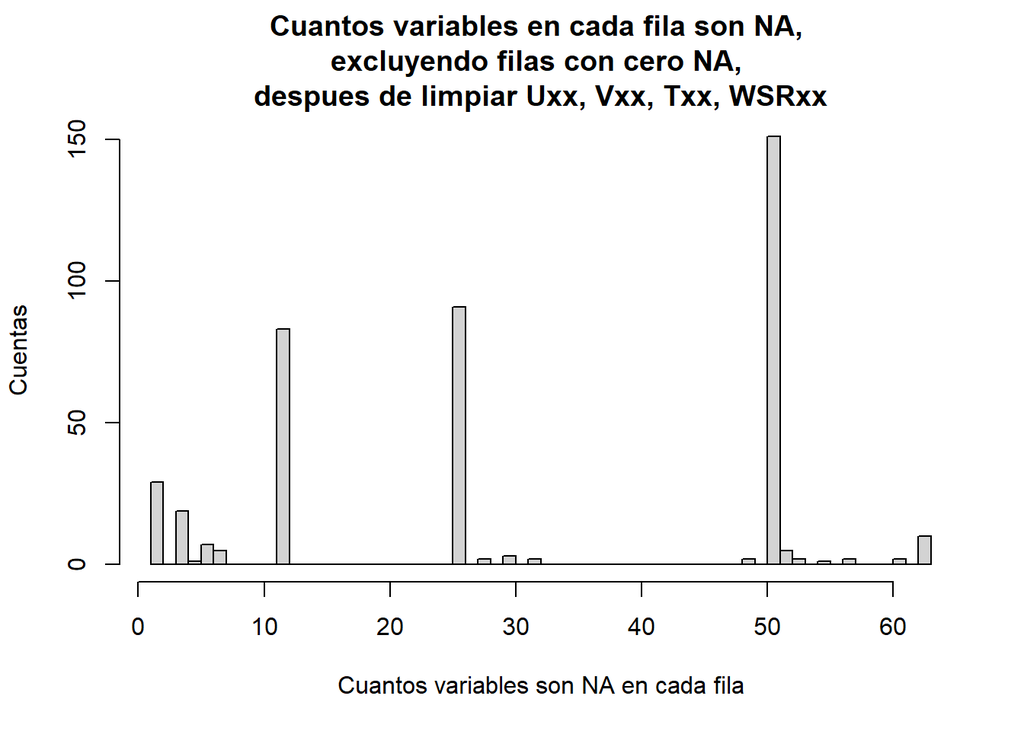

```r
# sweep by rows (margin = 1)
na_count_post_clean.T.WSR <- apply(data_cleaned, MARGIN=1, count_nas_in_row)

# histogram count of NAs per row
# Note, zeros will be excluded because are "NA" instead from function above
hist(na_count_post_clean.T.WSR, breaks=50, xlab="Cuantos variables son NA en cada fila", ylab="Cuentas", main="Cuantos variables en cada fila son NA, \nexcluyendo filas con cero NA, \ndespues de limpiar Uxx, Vxx, Txx, WSRxx")
```

Y lo mismo para los días de ozono:

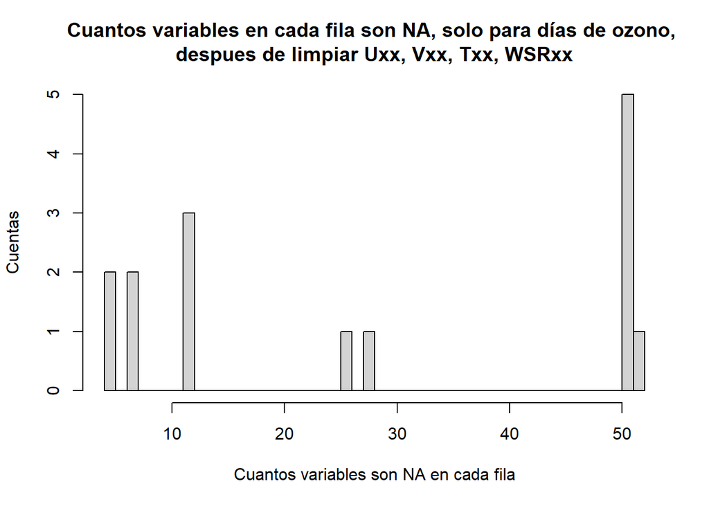

```r
# sweep by rows (margin = 1)
na_count_oz_post_clean.T.WSR <- apply(data_cleaned, MARGIN=1, count_nas_in_row_if_Oz)

# histogram count of NAs per row
# Note, zeros will be excluded because are "NA" instead from function
hist(na_count_oz_post_clean.T.WSR, breaks=50, xlab="Cuantos variables son NA en cada fila", ylab="Cuentas", main="Cuantos variables en cada fila son NA, solo para días de ozono, \ndespues de limpiar Uxx, Vxx, Txx, WSRxx")
```

Los casos con 51 faltando debe ser los casos que faltan todos los datos horarios, que también implica la falta de WSR_AV, WSR_PK, T_PK. Hay unos con 49 faltando, y esos son los casos a los bordes del bloque donde falta los datos diarios, en cuales hemos podido imputar nada más que T0 y/o T23.

Lo que intentaré hacer con esos filas es hacer imputación kNN, pero *después* de hacer la transformación de los Txx, WSRxx a vectores. No tengo justificación concreta, pero me parece más razonable hacer kNN para solo 5 valores (vector Txx, valor T_PK, vector WSRxx, valor WSR_AV, valor WSR_PK) que para cada valor númerico Txx, WSRxx. Esa imputación propuesta se basará en los valores de los otros variables diarios, y por tanto tenemos que tenerles todos intactos y reales. Por tanto, no deberiamos tratar cualquier fila que falta más que 51 valores. Debemos borrar esas filas. Haremos eso antes de seguir.

```r
indices.to.delete.missing.excessive.data <- which(na_count_post_clean.T.WSR > 51)

#which(na_count_post_clean.T.WSR == 51)
#which(na_count_post_clean.T.WSR == 50)

length(indices.to.delete.missing.excessive.data)
```

```
## [1] 22
```

```r
head(indices.to.delete.missing.excessive.data)
```

```
## 1632 1633 1652 1673 1674 1675
## 1632 1633 1652 1673 1674 1675
```

```r
#data_cleaned[1632:1633, ]
data_cleaned <- data_cleaned[-indices.to.delete.missing.excessive.data, ]

rownames(data_cleaned) <- 1:nrow(data_cleaned)
```

```r
nrow(data_cleaned)
```

```
## [1] 2514
```

Ya tenemos 22 filas menos.

Volveremos después a la imputación, tras hacer el clustering definitivo de los vectores Txx, WSRxx.

### 3.5.4 Seguimiento investigación limpieza

Tenemos que seguir investigando donde tenemos NAs que posiblemente podemos tratar. Después de quitar filar tenemos que re-buscar cuales filas tienen NAs.

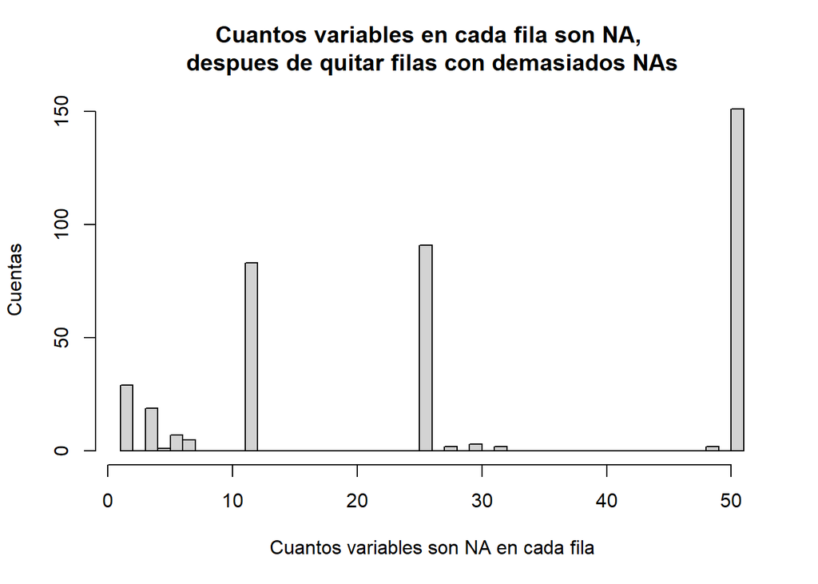

```r
# sweep by rows (margin = 1)
na_count_post.delete <- apply(data_cleaned, MARGIN=1, count_nas_in_row)

# histogram count of NAs per row
# Note, zeros will be excluded because are "NA" instead from function above
hist(na_count_post.delete, breaks=50, xlab="Cuantos variables son NA en cada fila", ylab="Cuentas", main="Cuantos variables en cada fila son NA, \ndespues de quitar filas con demasiados NAs")
```

Y lo mismo para los días de ozono:

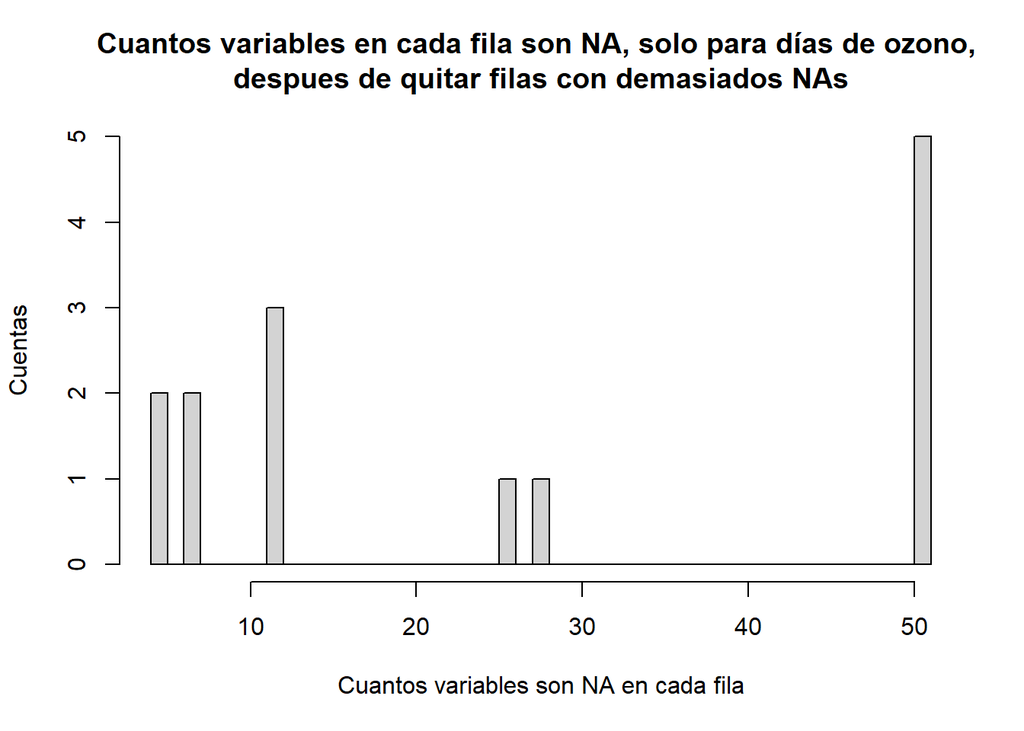

```r
# sweep by rows (margin = 1)
na_count_oz_post.delete <- apply(data_cleaned, MARGIN=1, count_nas_in_row_if_Oz)

# histogram count of NAs per row
# Note, zeros will be excluded because are "NA" instead from function
hist(na_count_oz_post.delete, breaks=50, xlab="Cuantos variables son NA en cada fila", ylab="Cuentas", main="Cuantos variables en cada fila son NA, solo para días de ozono, \ndespues de quitar filas con demasiados NAs")
```

Miramos de nuevo los casos por los días de ozono:

- 4NAs: dos casos (925, 2365) de dos parejas de Uxx, Vxx, como hemos visto anteriormente, U85, V85, U70, V70 en ambos. Se podría aceptar hacer kNN sobre las filas enteras para imputarlas.
- 7NAs: dos casos (236, 572) de datos diarios T70, U70, V70, T50, RH50, U50, V50 que faltan, como hemos visto anteriormente. Se podría aceptar hacer kNN sobre las filas enteras para imputarlas.
- 12NAs: tres casos (269, 489, 933) de todos datos diarios faltando
- 26NAs: un caso (283) de falta de todos los WSRxx, WSR_AV, WSR_PK
- 28NAs: un caso (279) de falta de todos los WSRxx, WSR_AV, WSR_PK, más T50, RH50

Para esos dos últimos, me parece que un kNN() con los vectores ya clasificados sería lo mejor, después de imputar los valores T50, RH50.

```r
na_count_oz_post.delete[which(na_count_oz_post.delete < 30)]
```

```
##  236  269  279  283  489  572  925  933 2365
##    7   12   28   26   12    7    4   12    4
```

```r
# 4 NA
data_cleaned[925, ]
```

```
##           DATE WSR0 WSR1 WSR2 WSR3 WSR4 WSR5 WSR6 WSR7 WSR8 WSR9 WSR10 WSR11
## 925 2000-07-24 0.09  0.1 0.12 0.09 0.05 0.04  0.1 0.09 0.13 0.12  0.21  0.15
##     WSR12 WSR13 WSR14 WSR15 WSR16 WSR17 WSR18 WSR19 WSR20 WSR21 WSR22 WSR23
## 925  0.13  0.09   0.1  0.21  0.14  0.15  0.14  0.09  0.15  0.17  0.15  0.11
##     WSR_PK WSR_AV    T0    T1    T2    T3    T4    T5    T6    T7    T8    T9
## 925   0.21   0.12 0.564 0.556 0.554 0.554 0.552 0.552 0.566 0.582 0.596 0.622
##      T10   T11   T12   T13   T14   T15   T16   T17   T18   T19   T20   T21  T22
## 925 0.66 0.684 0.704 0.724 0.742 0.758 0.762 0.764 0.752 0.718 0.676 0.654 0.64
##      T23  T_PK       T85 RH85 U85 V85       T70 U70 V70       T50 RH50    U50
## 925 0.63 0.764 0.7626582 0.68  NA  NA 0.6475096  NA  NA 0.6796537  0.4 0.2004
##         V50  SLP Precp OzoneDay1hPeak Oz8h
## 925 -0.2098 0.48     0              0    1
```

```r
data_cleaned[2365, ]
```

```
##            DATE WSR0 WSR1 WSR2 WSR3 WSR4 WSR5 WSR6 WSR7 WSR8 WSR9 WSR10 WSR11
## 2365 2004-08-04 0.06 0.12 0.08 0.04 0.04 0.04 0.05 0.24 0.27 0.23  0.17  0.13
##      WSR12 WSR13 WSR14 WSR15 WSR16 WSR17 WSR18 WSR19 WSR20 WSR21 WSR22 WSR23
## 2365  0.05  0.07   0.1  0.11  0.15  0.18  0.19  0.23  0.17  0.12  0.14  0.12
##      WSR_PK WSR_AV    T0    T1    T2    T3    T4    T5    T6    T7   T8    T9
## 2365   0.27   0.13 0.654 0.646 0.642 0.634 0.634 0.638 0.636 0.656 0.68 0.708
##        T10  T11   T12   T13   T14   T15   T16  T17   T18   T19   T20   T21
## 2365 0.728 0.75 0.762 0.778 0.786 0.794 0.798 0.79 0.762 0.724 0.702 0.686
##        T22   T23  T_PK       T85 RH85 U85 V85       T70 U70 V70       T50 RH50
## 2365 0.674 0.662 0.798 0.8575949 0.38  NA  NA 0.7011494  NA  NA 0.8831169 0.13
##          U50     V50       SLP Precp OzoneDay1hPeak Oz8h
## 2365 -0.1798 -0.1648 0.3733333     0              0    1
```

```r
# 7 NA
data_cleaned[236, ]
```

```
##           DATE WSR0 WSR1 WSR2 WSR3 WSR4 WSR5 WSR6 WSR7 WSR8 WSR9 WSR10 WSR11
## 236 1998-08-28 0.11 0.12 0.08 0.05 0.08  0.1  0.1 0.21 0.27 0.21  0.19  0.08
##     WSR12 WSR13 WSR14 WSR15 WSR16 WSR17 WSR18 WSR19 WSR20 WSR21 WSR22 WSR23
## 236  0.02  0.08  0.06  0.12  0.16  0.19  0.11  0.15  0.13  0.12  0.15  0.15
##     WSR_PK WSR_AV    T0    T1    T2    T3   T4   T5    T6    T7    T8    T9
## 236   0.27   0.13 0.646 0.634 0.618 0.612 0.61 0.61 0.612 0.646 0.692 0.724
##       T10  T11   T12   T13   T14   T15   T16   T17   T18   T19  T20   T21   T22
## 236 0.752 0.78 0.796 0.806 0.814 0.822 0.822 0.806 0.766 0.734 0.71 0.692 0.682
##       T23  T_PK       T85 RH85     U85     V85 T70 U70 V70 T50 RH50 U50 V50
## 236 0.674 0.822 0.8607595 0.66 -0.0954 -0.0256  NA  NA  NA  NA   NA  NA  NA
##      SLP Precp OzoneDay1hPeak Oz8h
## 236 0.44     0              0    1
```

```r
data_cleaned[572, ]
```

```
##           DATE WSR0 WSR1 WSR2 WSR3 WSR4 WSR5 WSR6 WSR7 WSR8 WSR9 WSR10 WSR11
## 572 1999-08-05 0.02 0.07 0.08 0.06 0.07 0.11 0.08  0.1 0.21 0.18  0.17  0.13
##     WSR12 WSR13 WSR14 WSR15 WSR16 WSR17 WSR18 WSR19 WSR20 WSR21 WSR22 WSR23
## 572   0.2  0.24   0.3  0.35   0.3  0.28  0.23  0.16  0.18  0.16  0.12  0.05
##     WSR_PK WSR_AV    T0    T1    T2   T3    T4    T5   T6    T7    T8    T9
## 572   0.35   0.16 0.632 0.624 0.624 0.62 0.616 0.612 0.61 0.652 0.688 0.726
##       T10   T11   T12   T13   T14   T15   T16   T17   T18   T19   T20   T21
## 572 0.766 0.788 0.808 0.816 0.826 0.828 0.818 0.806 0.778 0.744 0.722 0.698
##      T22   T23  T_PK       T85 RH85     U85    V85 T70 U70 V70 T50 RH50 U50 V50
## 572 0.69 0.662 0.828 0.8765823 0.34 -0.0826 -0.118  NA  NA  NA  NA   NA  NA  NA
##     SLP Precp OzoneDay1hPeak Oz8h
## 572 0.4     0              0    1
```

```r
# 12 NA
data_cleaned[269, ]
```

```
##           DATE WSR0 WSR1 WSR2 WSR3 WSR4 WSR5 WSR6 WSR7 WSR8 WSR9 WSR10 WSR11
## 269 1998-09-30 0.01 0.01 0.01 0.01 0.02 0.01 0.01    0 0.11 0.14  0.07  0.07
##     WSR12 WSR13 WSR14 WSR15 WSR16 WSR17 WSR18 WSR19 WSR20 WSR21 WSR22 WSR23
## 269  0.07  0.11  0.14  0.17  0.18  0.09  0.11  0.06  0.03  0.01     0  0.01
##     WSR_PK WSR_AV    T0    T1    T2    T3    T4    T5    T6    T7    T8    T9
## 269   0.18   0.06 0.598 0.594 0.592 0.584 0.572 0.562 0.562 0.606 0.678 0.724
##       T10   T11   T12  T13   T14   T15  T16  T17   T18   T19   T20   T21   T22
## 269 0.754 0.772 0.782 0.78 0.784 0.786 0.78 0.75 0.706 0.682 0.654 0.642 0.626
##       T23  T_PK T85 RH85 U85 V85 T70 U70 V70 T50 RH50 U50 V50 SLP Precp
## 269 0.606 0.786  NA   NA  NA  NA  NA  NA  NA  NA   NA  NA  NA  NA     0
##     OzoneDay1hPeak Oz8h
## 269              1    1
```

```r
data_cleaned[489, ]
```

```
##           DATE WSR0 WSR1 WSR2 WSR3 WSR4 WSR5 WSR6 WSR7 WSR8 WSR9 WSR10 WSR11
## 489 1999-05-08    0 0.01 0.01 0.02 0.02 0.03 0.09 0.07 0.13 0.21  0.21  0.26
##     WSR12 WSR13 WSR14 WSR15 WSR16 WSR17 WSR18 WSR19 WSR20 WSR21 WSR22 WSR23
## 489  0.15  0.13  0.25  0.34  0.41  0.42  0.38  0.31   0.2  0.24  0.26  0.21
##     WSR_PK WSR_AV    T0    T1    T2    T3    T4    T5    T6    T7    T8    T9
## 489   0.42   0.18 0.438 0.426 0.416 0.408 0.396 0.386 0.428 0.514 0.592 0.652
##       T10  T11   T12   T13  T14   T15   T16   T17  T18   T19  T20   T21   T22
## 489 0.694 0.72 0.734 0.736 0.74 0.736 0.714 0.676 0.63 0.596 0.57 0.552 0.548
##       T23 T_PK T85 RH85 U85 V85 T70 U70 V70 T50 RH50 U50 V50 SLP Precp
## 489 0.552 0.74  NA   NA  NA  NA  NA  NA  NA  NA   NA  NA  NA  NA     0
##     OzoneDay1hPeak Oz8h
## 489              1    1
```

```r
data_cleaned[933, ]
```

```
##           DATE WSR0 WSR1 WSR2 WSR3 WSR4 WSR5 WSR6 WSR7 WSR8 WSR9 WSR10 WSR11
## 933 2000-08-01 0.09 0.08 0.07 0.08 0.07  0.1 0.14 0.14 0.23 0.27  0.24  0.17
##     WSR12 WSR13 WSR14 WSR15 WSR16 WSR17 WSR18 WSR19 WSR20 WSR21 WSR22 WSR23
## 933     0  0.16  0.16  0.21  0.27  0.37  0.36  0.31  0.26  0.22  0.18  0.15
##     WSR_PK WSR_AV    T0    T1    T2    T3    T4    T5    T6    T7    T8    T9
## 933   0.37   0.18 0.552 0.552 0.548 0.546 0.546 0.542 0.544 0.562 0.602 0.644
##       T10   T11  T12   T13   T14   T15   T16   T17   T18  T19   T20   T21   T22
## 933 0.674 0.698 0.72 0.742 0.758 0.772 0.764 0.748 0.714 0.68 0.656 0.642 0.634
##       T23  T_PK T85 RH85 U85 V85 T70 U70 V70 T50 RH50 U50 V50 SLP Precp
## 933 0.626 0.772  NA   NA  NA  NA  NA  NA  NA  NA   NA  NA  NA  NA     0
##     OzoneDay1hPeak Oz8h
## 933              1    1
```

```r
# 26 NA
data_cleaned[283, ]
```

```
##           DATE WSR0 WSR1 WSR2 WSR3 WSR4 WSR5 WSR6 WSR7 WSR8 WSR9 WSR10 WSR11
## 283 1998-10-14   NA   NA   NA   NA   NA   NA   NA   NA   NA   NA    NA    NA
##     WSR12 WSR13 WSR14 WSR15 WSR16 WSR17 WSR18 WSR19 WSR20 WSR21 WSR22 WSR23
## 283    NA    NA    NA    NA    NA    NA    NA    NA    NA    NA    NA    NA
##     WSR_PK WSR_AV    T0    T1    T2    T3    T4    T5    T6    T7    T8    T9
## 283     NA     NA 0.478 0.476 0.464 0.452 0.448 0.446 0.444 0.466 0.522 0.576
##       T10   T11   T12   T13   T14   T15   T16   T17  T18   T19   T20   T21
## 283 0.618 0.644 0.648 0.654 0.656 0.654 0.644 0.608 0.57 0.546 0.534 0.524
##       T22   T23  T_PK       T85 RH85    U85   V85       T70    U70     V70
## 283 0.506 0.502 0.656 0.7563291 0.04 0.0166 -0.02 0.5900383 0.1202 -0.0708
##           T50 RH50    U50    V50       SLP Precp OzoneDay1hPeak Oz8h
## 283 0.6363636 0.06 0.0568 -0.052 0.4933333     0              1    1
```

```r
# 28 NA
data_cleaned[279, ]
```

```
##           DATE WSR0 WSR1 WSR2 WSR3 WSR4 WSR5 WSR6 WSR7 WSR8 WSR9 WSR10 WSR11
## 279 1998-10-10   NA   NA   NA   NA   NA   NA   NA   NA   NA   NA    NA    NA
##     WSR12 WSR13 WSR14 WSR15 WSR16 WSR17 WSR18 WSR19 WSR20 WSR21 WSR22 WSR23
## 279    NA    NA    NA    NA    NA    NA    NA    NA    NA    NA    NA    NA
##     WSR_PK WSR_AV    T0    T1    T2    T3   T4    T5    T6    T7    T8    T9
## 279     NA     NA 0.414 0.416 0.402 0.396 0.39 0.388 0.394 0.424 0.488 0.536
##       T10   T11   T12   T13   T14  T15   T16   T17   T18 T19   T20  T21   T22
## 279 0.564 0.584 0.594 0.604 0.616 0.62 0.608 0.572 0.526 0.5 0.478 0.46 0.452
##      T23 T_PK       T85 RH85    U85     V85       T70    U70    V70 T50 RH50
## 279 0.44 0.62 0.6993671 0.02 -0.015 -0.0324 0.8084291 0.0288 0.0336  NA   NA
##        U50    V50       SLP Precp OzoneDay1hPeak Oz8h
## 279 0.2068 0.0018 0.5333333     0              1    1
```

Está claro que usar imputación kNN con esos casos resultará en el arreglo de casos con bajo ozono también, pero no es nuestro prioridad.

Procedemos con una imputación kNN que cubrirá todos los variables diarias aparte de Precp: T85, RH85, U85, V85, T70, U70, V70, T50, RH50, U50, V50, SLP. Por las filas en que hay valores parciales diarias, será solo por la parte que falta. Incluiremos los clases de ozono en los datos - cosa que podría incluso estar interpretado como algo cerca a *over-sampling*, porqué estaremos dando un poco de influencia a los casos de ozono alta para crear valores imputados que se parecen más a los días de ozono.

```r
data_cleaned_full.imputation <- kNN(data_cleaned, variable=c("T85", "RH85", "U85", "V85", "T70", "U70", "V70", "T50", "RH50", "U50", "V50", "SLP"), k=5)

head(data_cleaned_full.imputation)
```

```
##         DATE WSR0 WSR1 WSR2 WSR3 WSR4 WSR5 WSR6 WSR7 WSR8 WSR9 WSR10 WSR11
## 1 1998-01-01 0.08 0.18 0.24 0.21 0.20 0.21 0.15 0.17 0.19 0.23  0.37  0.55
## 2 1998-01-02 0.28 0.32 0.33 0.27 0.33 0.32 0.29 0.28 0.31 0.34  0.42  0.45
## 3 1998-01-03 0.29 0.28 0.26 0.21 0.22 0.25 0.25 0.27 0.22 0.25  0.31  0.40
## 4 1998-01-04 0.47 0.38 0.37 0.38 0.29 0.31 0.28 0.25 0.24 0.31  0.33  0.31
## 5 1998-01-05 0.26 0.21 0.16 0.14 0.09 0.15 0.12 0.14 0.13 0.14  0.22  0.20
## 6 1998-01-06 0.31 0.35 0.33 0.25 0.16 0.17 0.16 0.16 0.23 0.18  0.25  0.39
##   WSR12 WSR13 WSR14 WSR15 WSR16 WSR17 WSR18 WSR19 WSR20 WSR21 WSR22 WSR23
## 1  0.51  0.54  0.54  0.47  0.43  0.35  0.35  0.29  0.32  0.32  0.28  0.26
## 2  0.45  0.43  0.55  0.51  0.38  0.30  0.26  0.30  0.22  0.23  0.25  0.28
## 3  0.44  0.46  0.56  0.54  0.52  0.44  0.35  0.27  0.29  0.39  0.41  0.46
## 4  0.23  0.21  0.22  0.38  0.28  0.24  0.19  0.32  0.41  0.39  0.45  0.43
## 5  0.30  0.30  0.31  0.31  0.27  0.30  0.24  0.28  0.25  0.25  0.37  0.34
## 6  0.34  0.27  0.34  0.25  0.22  0.44  0.43  0.32  0.62  0.68  0.51  0.40
##   WSR_PK WSR_AV    T0    T1    T2    T3    T4    T5    T6    T7    T8    T9
```

[output cut: 41 more lines]

```r
nrow(data_cleaned_full.imputation)
```

```
## [1] 2514
```

```r
head(data_cleaned_full.imputation[, 1:67])
```

```
##         DATE WSR0 WSR1 WSR2 WSR3 WSR4 WSR5 WSR6 WSR7 WSR8 WSR9 WSR10 WSR11
## 1 1998-01-01 0.08 0.18 0.24 0.21 0.20 0.21 0.15 0.17 0.19 0.23  0.37  0.55
## 2 1998-01-02 0.28 0.32 0.33 0.27 0.33 0.32 0.29 0.28 0.31 0.34  0.42  0.45
## 3 1998-01-03 0.29 0.28 0.26 0.21 0.22 0.25 0.25 0.27 0.22 0.25  0.31  0.40
## 4 1998-01-04 0.47 0.38 0.37 0.38 0.29 0.31 0.28 0.25 0.24 0.31  0.33  0.31
## 5 1998-01-05 0.26 0.21 0.16 0.14 0.09 0.15 0.12 0.14 0.13 0.14  0.22  0.20
## 6 1998-01-06 0.31 0.35 0.33 0.25 0.16 0.17 0.16 0.16 0.23 0.18  0.25  0.39
##   WSR12 WSR13 WSR14 WSR15 WSR16 WSR17 WSR18 WSR19 WSR20 WSR21 WSR22 WSR23
## 1  0.51  0.54  0.54  0.47  0.43  0.35  0.35  0.29  0.32  0.32  0.28  0.26
## 2  0.45  0.43  0.55  0.51  0.38  0.30  0.26  0.30  0.22  0.23  0.25  0.28
## 3  0.44  0.46  0.56  0.54  0.52  0.44  0.35  0.27  0.29  0.39  0.41  0.46
## 4  0.23  0.21  0.22  0.38  0.28  0.24  0.19  0.32  0.41  0.39  0.45  0.43
## 5  0.30  0.30  0.31  0.31  0.27  0.30  0.24  0.28  0.25  0.25  0.37  0.34
## 6  0.34  0.27  0.34  0.25  0.22  0.44  0.43  0.32  0.62  0.68  0.51  0.40
##   WSR_PK WSR_AV    T0    T1    T2    T3    T4    T5    T6    T7    T8    T9
```

[output cut: 27 more lines]

Podemos quitar las columnas indicando imputación hecha.

```r
data_cleaned_full.imputation <- data_cleaned_full.imputation[, 1:67]
```

Ahora volvemos a mirar que tenemos de NAs para planificar los siguientes pasos.

```r
# sweep by rows (margin = 1)
na_count_post.delete <- apply(data_cleaned_full.imputation, MARGIN=1, count_nas_in_row)

table(na_count_post.delete)
```

```
## na_count_post.delete
##   1  26  49  51
##   2  98   2 151
```

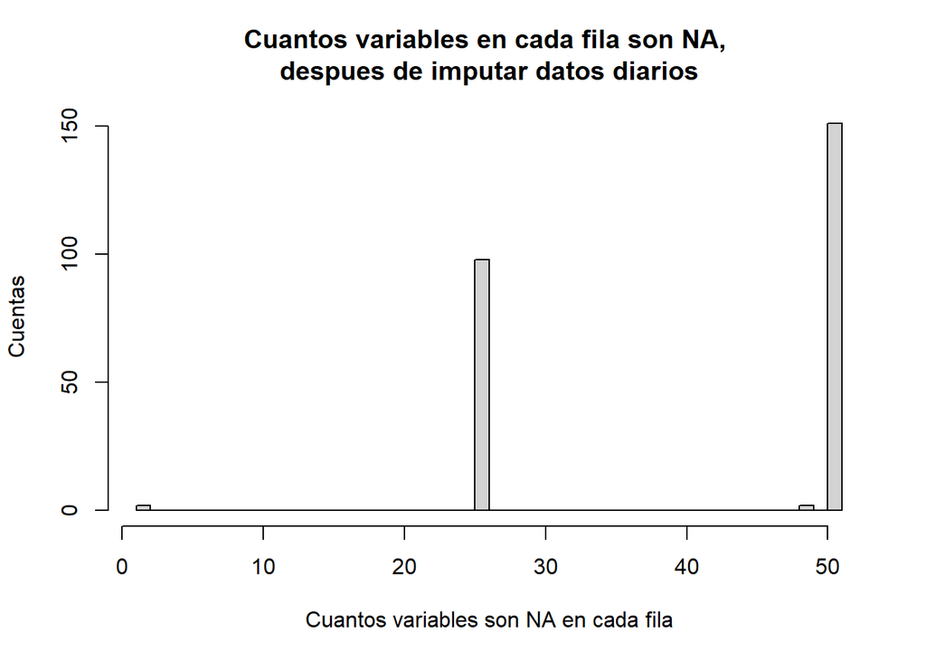

```r
# histogram count of NAs per row
# Note, zeros will be excluded because are "NA" instead from function above
hist(na_count_post.delete, breaks=50, xlab="Cuantos variables son NA en cada fila", ylab="Cuentas", main="Cuantos variables en cada fila son NA, \ndespues de imputar datos diarios")
```

Y lo mismo para los días de ozono:

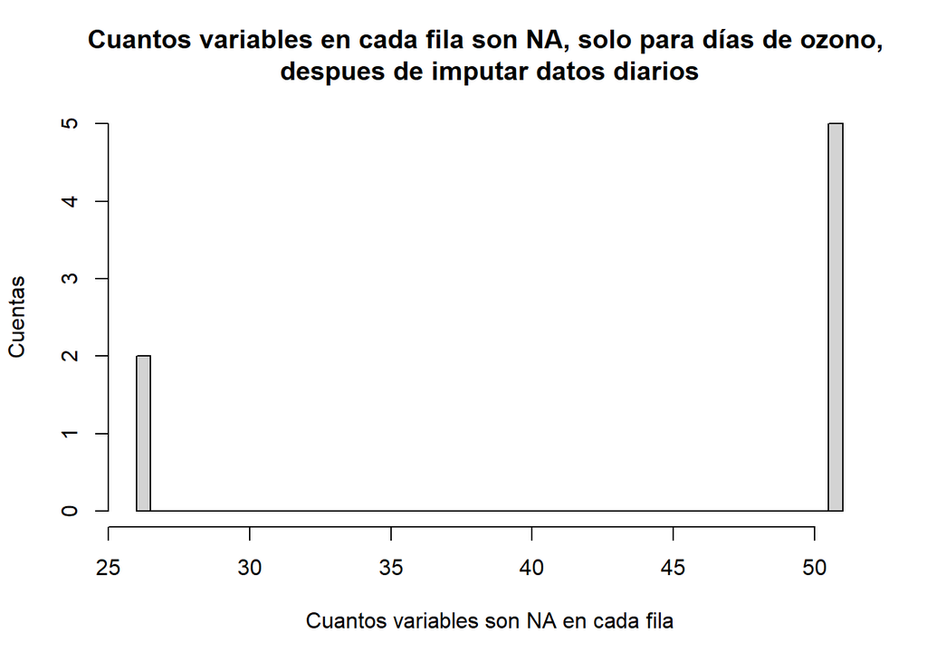

```r
# sweep by rows (margin = 1)
na_count_oz_post.delete <- apply(data_cleaned_full.imputation, MARGIN=1, count_nas_in_row_if_Oz)

# histogram count of NAs per row
# Note, zeros will be excluded because are "NA" instead from function
hist(na_count_oz_post.delete, breaks=50, xlab="Cuantos variables son NA en cada fila", ylab="Cuentas", main="Cuantos variables en cada fila son NA, solo para días de ozono, \ndespues de imputar datos diarios")
```

Entonces, solo nos quedan hacer las transformaciones de los vectores, y después un segundo paso por kNN usando las clasificaciones de los vectores. Tras esos pasos, habrá todavía NAs en WSR_AV, WSR_PK, y T_PK que tendremos, de nuevo, imputar.

### 3.5.5 Transformación de vectores Txx, WSRxx usando MClust

Anteriormente, hemos elegido como queremos transformar los datos horarios de temperatura y velocidad del viento, clasificándolos como vectores, en clusters, pero no lo hemos hecho en el apartado de Conversión, como que faltaba muchos valores. Ahora con los trabajos de imputación, hemos reducido al mínimo los NAs y ahora es el momento de hacer la conversión y clasificación.

Lo haremos aislando las filas sin NAs, dejando las filas con NAs con un valor de vector NA, que imputaremos después.

Los métodos elegidos anteriormente son:

- Txx: MClust modelo VVV con G=8.
- WSRxx: MClust modelo VVV con G=6.

En ambos casos, tenemos ya modelos ajustados, hechos con datos “enteros” con filas incluyendo cualquier NA quitada. Se puede re-usar esos modelos para predecir de nuevo la clasificación de cada vector de Txx y WSRxx. Pero, no podemos pasar las filas con vectores totalmente NA al modelo - tendremos que filtrar los indicios de las filas validas, y por esas filas añadir las dos columnas de clasificación de vector. Por las filas con vectores NA, pondremos NA.

#### 3.5.5.1 Clustering definitivo Txx

El modelo ya ajustado es en mclust_VVV8_temps.

```r
# Fetch indices for rows which will get a Txx vector classificaction (rows with no NAs)
indices.full.Txxs <- which(complete.cases(data_cleaned_full.imputation[28:51]) == TRUE)

# Classify vectors using model
# Store "classification" object into a vector to add to dataframe
full.Txx.vector.classification <- predict(mclust_VVV8_temps,
                                          na.omit(data_cleaned_full.imputation[28:51]))$classification

Txx.vectors.indexed <- data.frame(vector = full.Txx.vector.classification)
rownames(Txx.vectors.indexed) <- indices.full.Txxs
```

```r
# Check lengths etc
length(indices.full.Txxs)
```

```
## [1] 2361
```

```r
length(full.Txx.vector.classification)
```

```
## [1] 2361
```

```r
nrow(Txx.vectors.indexed)
```

```
## [1] 2361
```

```r
head(Txx.vectors.indexed, 1)
```

```
##   vector
## 1      5
```

```r
tail(Txx.vectors.indexed, 1)
```

```
##      vector
## 2514      3
```

Añadimos columnas extras para clase de vector Txx, WSRxx y remplazamos los valores en filas clasificadas por el valor generado por el modelo.

```r
# Add two empty columns to prepare dataframe
data_cleaned_vector.classes <- cbind(data_cleaned_full.imputation, WSR.vect = NA, T.vect = NA)

# Match up vector classes from model prediction to their rows
# rownames of Txx.vectors.indexed is already set to the target indices' values
data_cleaned_vector.classes$T.vect[rownames(data_cleaned_vector.classes)
                                   %in%
                                     indices.full.Txxs] <- Txx.vectors.indexed$vector

head(data_cleaned_vector.classes, 1)
```

```
##         DATE WSR0 WSR1 WSR2 WSR3 WSR4 WSR5 WSR6 WSR7 WSR8 WSR9 WSR10 WSR11
## 1 1998-01-01 0.08 0.18 0.24 0.21  0.2 0.21 0.15 0.17 0.19 0.23  0.37  0.55
##   WSR12 WSR13 WSR14 WSR15 WSR16 WSR17 WSR18 WSR19 WSR20 WSR21 WSR22 WSR23
## 1  0.51  0.54  0.54  0.47  0.43  0.35  0.35  0.29  0.32  0.32  0.28  0.26
##   WSR_PK WSR_AV    T0    T1    T2    T3    T4    T5    T6    T7    T8    T9
## 1   0.55   0.31 0.204 0.222 0.222 0.222 0.222 0.212 0.204 0.208 0.244 0.312
##    T10   T11   T12   T13   T14   T15   T16   T17   T18   T19   T20   T21   T22
## 1 0.39 0.444 0.466 0.478 0.482 0.478 0.466 0.446 0.436 0.422 0.408 0.398 0.396
##   T23  T_PK       T85 RH85    U85    V85       T70    U70    V70       T50 RH50
## 1 0.4 0.482 0.4367089 0.11 0.0766 0.0028 0.2911877 0.1436 0.0024 0.4025974 0.15
##      U50     V50       SLP Precp OzoneDay1hPeak Oz8h WSR.vect T.vect
## 1 0.2134 -0.0312 0.9466667     0              0    0       NA      5
```

```r
tail(data_cleaned_vector.classes, 1)
```

```
##            DATE WSR0 WSR1 WSR2 WSR3 WSR4 WSR5 WSR6 WSR7 WSR8 WSR9 WSR10 WSR11
## 2514 2004-12-31 0.15 0.13 0.18 0.14 0.12 0.17 0.16 0.14 0.16  0.3  0.36  0.32
##      WSR12 WSR13 WSR14 WSR15 WSR16 WSR17 WSR18 WSR19 WSR20 WSR21 WSR22 WSR23
## 2514  0.33   0.4  0.31  0.34  0.38   0.3  0.25  0.21  0.32  0.28  0.31  0.32
##      WSR_PK WSR_AV    T0    T1    T2    T3  T4    T5  T6    T7    T8    T9
## 2514    0.4   0.25 0.476 0.476 0.494 0.502 0.5 0.496 0.5 0.504 0.506 0.496
##        T10   T11  T12  T13   T14   T15   T16   T17  T18   T19   T20   T21   T22
## 2514 0.524 0.546 0.56 0.57 0.562 0.548 0.534 0.506 0.49 0.504 0.518 0.524 0.516
##        T23 T_PK       T85 RH85    U85    V85       T70    U70    V70       T50
## 2514 0.508 0.57 0.5443038 0.74 0.0406 0.1624 0.5670498 0.1382 0.0486 0.5584416
##      RH50    U50   V50       SLP Precp OzoneDay1hPeak Oz8h WSR.vect T.vect
## 2514 0.54 0.2614 0.183 0.6533333     0              0    0       NA      3
```

```r
nrow(data_cleaned_vector.classes[is.na(data_cleaned_vector.classes$T.vect), ])
```

```
## [1] 153
```

El numero de NAs restante en T.vect es 153, que es la diferencia esperada, de 2514-2361.

#### 3.5.5.2 Clustering definitivo WSRxx

Haciendo el análogo para los WSR’s:

```r
# Fetch indices for rows which will get a WSRxx vector classificaction (rows with no NAs)
indices.full.WSRxxs <- which(complete.cases(data_cleaned_full.imputation[2:25]) == TRUE)

# Classify vectors using model
# Store "classification" object into a vector to add to dataframe
full.WSRxx.vector.classification <- predict(mclust_G6_WSR,
                                          na.omit(data_cleaned_full.imputation[2:25]))$classification

WSRxx.vectors.indexed <- data.frame(vector = full.WSRxx.vector.classification)
rownames(WSRxx.vectors.indexed) <- indices.full.WSRxxs
```

```r
# Check lengths etc
length(indices.full.WSRxxs)
```

```
## [1] 2263
```

```r
length(full.WSRxx.vector.classification)
```

```
## [1] 2263
```

```r
nrow(WSRxx.vectors.indexed)
```

```
## [1] 2263
```

```r
head(WSRxx.vectors.indexed, 1)
```

```
##   vector
## 1      3
```

```r
tail(WSRxx.vectors.indexed, 1)
```

```
##      vector
## 2514      3
```

Ya tenemos la columna hechoa para clase de vector WSRxx. Remplazamos los valores en filas clasificadas por el valor generado por el modelo.

```r
# Match up vector classes from model prediction to their rows
# rownames of Txx.vectors.indexed is already set to the target indices' values
data_cleaned_vector.classes$WSR.vect[rownames(data_cleaned_vector.classes)
                                   %in%
                                     indices.full.WSRxxs] <- WSRxx.vectors.indexed$vector

head(data_cleaned_vector.classes, 1)
```

```
##         DATE WSR0 WSR1 WSR2 WSR3 WSR4 WSR5 WSR6 WSR7 WSR8 WSR9 WSR10 WSR11
## 1 1998-01-01 0.08 0.18 0.24 0.21  0.2 0.21 0.15 0.17 0.19 0.23  0.37  0.55
##   WSR12 WSR13 WSR14 WSR15 WSR16 WSR17 WSR18 WSR19 WSR20 WSR21 WSR22 WSR23
## 1  0.51  0.54  0.54  0.47  0.43  0.35  0.35  0.29  0.32  0.32  0.28  0.26
##   WSR_PK WSR_AV    T0    T1    T2    T3    T4    T5    T6    T7    T8    T9
## 1   0.55   0.31 0.204 0.222 0.222 0.222 0.222 0.212 0.204 0.208 0.244 0.312
##    T10   T11   T12   T13   T14   T15   T16   T17   T18   T19   T20   T21   T22
## 1 0.39 0.444 0.466 0.478 0.482 0.478 0.466 0.446 0.436 0.422 0.408 0.398 0.396
##   T23  T_PK       T85 RH85    U85    V85       T70    U70    V70       T50 RH50
## 1 0.4 0.482 0.4367089 0.11 0.0766 0.0028 0.2911877 0.1436 0.0024 0.4025974 0.15
##      U50     V50       SLP Precp OzoneDay1hPeak Oz8h WSR.vect T.vect
## 1 0.2134 -0.0312 0.9466667     0              0    0        3      5
```

```r
tail(data_cleaned_vector.classes, 1)
```

```
##            DATE WSR0 WSR1 WSR2 WSR3 WSR4 WSR5 WSR6 WSR7 WSR8 WSR9 WSR10 WSR11
## 2514 2004-12-31 0.15 0.13 0.18 0.14 0.12 0.17 0.16 0.14 0.16  0.3  0.36  0.32
##      WSR12 WSR13 WSR14 WSR15 WSR16 WSR17 WSR18 WSR19 WSR20 WSR21 WSR22 WSR23
## 2514  0.33   0.4  0.31  0.34  0.38   0.3  0.25  0.21  0.32  0.28  0.31  0.32
##      WSR_PK WSR_AV    T0    T1    T2    T3  T4    T5  T6    T7    T8    T9
## 2514    0.4   0.25 0.476 0.476 0.494 0.502 0.5 0.496 0.5 0.504 0.506 0.496
##        T10   T11  T12  T13   T14   T15   T16   T17  T18   T19   T20   T21   T22
## 2514 0.524 0.546 0.56 0.57 0.562 0.548 0.534 0.506 0.49 0.504 0.518 0.524 0.516
##        T23 T_PK       T85 RH85    U85    V85       T70    U70    V70       T50
## 2514 0.508 0.57 0.5443038 0.74 0.0406 0.1624 0.5670498 0.1382 0.0486 0.5584416
##      RH50    U50   V50       SLP Precp OzoneDay1hPeak Oz8h WSR.vect T.vect
## 2514 0.54 0.2614 0.183 0.6533333     0              0    0        3      3
```

```r
nrow(data_cleaned_vector.classes[is.na(data_cleaned_vector.classes$WSR.vect), ])
```

```
## [1] 251
```

El numero de NAs restante en WSR.vect es 251, que es la diferencia esperada, de 2514-2263.

Antes de seguir, tenemos que convertir los clases de los vectores en Factors, como que no son valores numéricos, solo etiquetas.

```r
data_cleaned_vector.classes$T.vect <- as.factor(data_cleaned_vector.classes$T.vect)
data_cleaned_vector.classes$WSR.vect <- as.factor(data_cleaned_vector.classes$WSR.vect)
```

### 3.5.6 Imputación final para vectores T y WSR NA

Ahora podemos hacer los pasos finales de limpieza, de imputar los valores de los vectores de temperatura horaria y de velocidad del viento horario, y los valores NA de WSR_AV, WSR_PK, T_PK [como que estos faltan también cuando faltan todos los datos horarios], con kNN.

Lo hacemos en dos pasos.

1. Primero hacemos un subconjunto sin WSR_AV, WSR_PK, T_PK y sin los datos horarios, para imputar los clases de vectores. Luego remplazamos los vectores NA con esos valores imputados, de nuevo quitando las columnas que añade kNN().
2. Segundo, imputamos los valores WSR_AV, WSR_PK, T_PK que falten finalmente.

```r
# Subset to only have daily data and vectors
data_daily.vectors <- subset( data_cleaned_vector.classes, select = -c(2:25, 28:51))

head(data_daily.vectors, 1)
```

```
##         DATE WSR_PK WSR_AV  T_PK       T85 RH85    U85    V85       T70    U70
## 1 1998-01-01   0.55   0.31 0.482 0.4367089 0.11 0.0766 0.0028 0.2911877 0.1436
##      V70       T50 RH50    U50     V50       SLP Precp OzoneDay1hPeak Oz8h
## 1 0.0024 0.4025974 0.15 0.2134 -0.0312 0.9466667     0              0    0
##   WSR.vect T.vect
## 1        3      5
```

```r
# Perform kNN and overwrite NAs directly
data_daily.vectors <- kNN(data_daily.vectors, variable=c("T.vect", "WSR.vect"), k=5)

head(data_daily.vectors)
```

```
##         DATE WSR_PK WSR_AV  T_PK       T85 RH85     U85    V85       T70    U70
## 1 1998-01-01   0.55   0.31 0.482 0.4367089 0.11  0.0766 0.0028 0.2911877 0.1436
## 2 1998-01-02   0.55   0.34 0.548 0.5094937 0.25 -0.0082 0.1906 0.2950192 0.1648
## 3 1998-01-03   0.56   0.35 0.544 0.5094937 0.56  0.0178 0.2034 0.4137931 0.0760
## 4 1998-01-04   0.47   0.32 0.492 0.5379747 0.89 -0.0068 0.1716 0.4942529 0.0834
## 5 1998-01-05   0.37   0.23 0.620 0.6708861 0.78  0.0412 0.1902 0.6015326 0.1180
## 6 1998-01-06   0.68   0.32 0.492 0.6803797 0.68  0.0304 0.1724 0.5440613 0.1808
##      V70       T50 RH50    U50     V50       SLP      Precp OzoneDay1hPeak Oz8h
## 1 0.0024 0.4025974 0.15 0.2134 -0.0312 0.9466667 0.00000000              0    0
## 2 0.1460 0.4458874 0.48 0.1678  0.0768 0.8000000 0.00000000              0    0
## 3 0.0884 0.3852814 0.60 0.1388  0.1960 0.6933333 0.00000000              0    0
## 4 0.1622 0.3463203 0.49 0.1746  0.2108 0.5866667 0.10072639              0    0
## 5 0.0386 0.5930736 0.50 0.2614  0.1830 0.6266667 0.02808717              0    0
## 6 0.2162 0.5627706 0.09 0.2396  0.2256 0.3866667 0.28280872              0    0
##   WSR.vect T.vect T.vect_imp WSR.vect_imp
## 1        3      5      FALSE        FALSE
## 2        3      6      FALSE        FALSE
## 3        3      4      FALSE        FALSE
## 4        6      6      FALSE        FALSE
## 5        3      6      FALSE        FALSE
## 6        6      3      FALSE        FALSE
```

```r
nrow(data_daily.vectors)
```

```
## [1] 2514
```

```r
head(data_daily.vectors[, 1:21])
```

```
##         DATE WSR_PK WSR_AV  T_PK       T85 RH85     U85    V85       T70    U70
## 1 1998-01-01   0.55   0.31 0.482 0.4367089 0.11  0.0766 0.0028 0.2911877 0.1436
## 2 1998-01-02   0.55   0.34 0.548 0.5094937 0.25 -0.0082 0.1906 0.2950192 0.1648
## 3 1998-01-03   0.56   0.35 0.544 0.5094937 0.56  0.0178 0.2034 0.4137931 0.0760
## 4 1998-01-04   0.47   0.32 0.492 0.5379747 0.89 -0.0068 0.1716 0.4942529 0.0834
## 5 1998-01-05   0.37   0.23 0.620 0.6708861 0.78  0.0412 0.1902 0.6015326 0.1180
## 6 1998-01-06   0.68   0.32 0.492 0.6803797 0.68  0.0304 0.1724 0.5440613 0.1808
##      V70       T50 RH50    U50     V50       SLP      Precp OzoneDay1hPeak Oz8h
## 1 0.0024 0.4025974 0.15 0.2134 -0.0312 0.9466667 0.00000000              0    0
## 2 0.1460 0.4458874 0.48 0.1678  0.0768 0.8000000 0.00000000              0    0
## 3 0.0884 0.3852814 0.60 0.1388  0.1960 0.6933333 0.00000000              0    0
## 4 0.1622 0.3463203 0.49 0.1746  0.2108 0.5866667 0.10072639              0    0
## 5 0.0386 0.5930736 0.50 0.2614  0.1830 0.6266667 0.02808717              0    0
## 6 0.2162 0.5627706 0.09 0.2396  0.2256 0.3866667 0.28280872              0    0
##   WSR.vect T.vect
## 1        3      5
## 2        3      6
## 3        3      4
## 4        6      6
## 5        3      6
## 6        6      3
```

Verificamos que no hay vectores NA ahora:

```r
any(is.na(data_daily.vectors$T.vect) | is.na(data_daily.vectors$WSR.vect))
```

```
## [1] FALSE
```

Podemos quitar las columnas indicando imputación hecha.

```r
data_daily.vectors <- data_daily.vectors[, 1:21]
```

Hacemos el segundo pase de kNN para WSR_AV, WSR_PK, T_PK

```r
# Perform kNN and overwrite NAs directly
data_daily.vectors <- kNN(data_daily.vectors, variable=c("WSR_PK", "WSR_AV", "T_PK"), k=5)

head(data_daily.vectors)
```

```
##         DATE WSR_PK WSR_AV  T_PK       T85 RH85     U85    V85       T70    U70
## 1 1998-01-01   0.55   0.31 0.482 0.4367089 0.11  0.0766 0.0028 0.2911877 0.1436
## 2 1998-01-02   0.55   0.34 0.548 0.5094937 0.25 -0.0082 0.1906 0.2950192 0.1648
## 3 1998-01-03   0.56   0.35 0.544 0.5094937 0.56  0.0178 0.2034 0.4137931 0.0760
## 4 1998-01-04   0.47   0.32 0.492 0.5379747 0.89 -0.0068 0.1716 0.4942529 0.0834
## 5 1998-01-05   0.37   0.23 0.620 0.6708861 0.78  0.0412 0.1902 0.6015326 0.1180
## 6 1998-01-06   0.68   0.32 0.492 0.6803797 0.68  0.0304 0.1724 0.5440613 0.1808
##      V70       T50 RH50    U50     V50       SLP      Precp OzoneDay1hPeak Oz8h
## 1 0.0024 0.4025974 0.15 0.2134 -0.0312 0.9466667 0.00000000              0    0
## 2 0.1460 0.4458874 0.48 0.1678  0.0768 0.8000000 0.00000000              0    0
## 3 0.0884 0.3852814 0.60 0.1388  0.1960 0.6933333 0.00000000              0    0
## 4 0.1622 0.3463203 0.49 0.1746  0.2108 0.5866667 0.10072639              0    0
## 5 0.0386 0.5930736 0.50 0.2614  0.1830 0.6266667 0.02808717              0    0
## 6 0.2162 0.5627706 0.09 0.2396  0.2256 0.3866667 0.28280872              0    0
##   WSR.vect T.vect WSR_PK_imp WSR_AV_imp T_PK_imp
## 1        3      5      FALSE      FALSE    FALSE
## 2        3      6      FALSE      FALSE    FALSE
## 3        3      4      FALSE      FALSE    FALSE
## 4        6      6      FALSE      FALSE    FALSE
## 5        3      6      FALSE      FALSE    FALSE
## 6        6      3      FALSE      FALSE    FALSE
```

```r
nrow(data_daily.vectors)
```

```
## [1] 2514
```

```r
head(data_daily.vectors[, 1:21])
```

```
##         DATE WSR_PK WSR_AV  T_PK       T85 RH85     U85    V85       T70    U70
## 1 1998-01-01   0.55   0.31 0.482 0.4367089 0.11  0.0766 0.0028 0.2911877 0.1436
## 2 1998-01-02   0.55   0.34 0.548 0.5094937 0.25 -0.0082 0.1906 0.2950192 0.1648
## 3 1998-01-03   0.56   0.35 0.544 0.5094937 0.56  0.0178 0.2034 0.4137931 0.0760
## 4 1998-01-04   0.47   0.32 0.492 0.5379747 0.89 -0.0068 0.1716 0.4942529 0.0834
## 5 1998-01-05   0.37   0.23 0.620 0.6708861 0.78  0.0412 0.1902 0.6015326 0.1180
## 6 1998-01-06   0.68   0.32 0.492 0.6803797 0.68  0.0304 0.1724 0.5440613 0.1808
##      V70       T50 RH50    U50     V50       SLP      Precp OzoneDay1hPeak Oz8h
## 1 0.0024 0.4025974 0.15 0.2134 -0.0312 0.9466667 0.00000000              0    0
## 2 0.1460 0.4458874 0.48 0.1678  0.0768 0.8000000 0.00000000              0    0
## 3 0.0884 0.3852814 0.60 0.1388  0.1960 0.6933333 0.00000000              0    0
## 4 0.1622 0.3463203 0.49 0.1746  0.2108 0.5866667 0.10072639              0    0
## 5 0.0386 0.5930736 0.50 0.2614  0.1830 0.6266667 0.02808717              0    0
## 6 0.2162 0.5627706 0.09 0.2396  0.2256 0.3866667 0.28280872              0    0
##   WSR.vect T.vect
## 1        3      5
## 2        3      6
## 3        3      4
## 4        6      6
## 5        3      6
## 6        6      3
```

De nuevo, podemos quitar las columnas indicando imputación hecha.

```r
data_daily.vectors <- data_daily.vectors[, 1:21]
```

Finalmente, confirmamos que no tenemos NAs en el dataframe. Nos acordamos que ya hemos quitado los datos horarios anteriormente, en favor de usar los vectores clusterizados en su lugar.

```r
summary(data_daily.vectors)
```

```
##       DATE                WSR_PK           WSR_AV            T_PK
##  Min.   :1998-01-01   Min.   :0.0800   Min.   :0.0400   Min.   :0.1340
##  1st Qu.:1999-10-01   1st Qu.:0.3400   1st Qu.:0.1600   1st Qu.:0.5260
##  Median :2001-06-21   Median :0.4200   Median :0.2200   Median :0.6310
##  Mean   :2001-06-29   Mean   :0.4238   Mean   :0.2359   Mean   :0.6112
##  3rd Qu.:2003-04-11   3rd Qu.:0.4900   3rd Qu.:0.2900   3rd Qu.:0.7220
##  Max.   :2004-12-31   Max.   :0.9600   Max.   :0.6400   Max.   :0.9320
##
##       T85              RH85             U85                V85
##  Min.   :0.0000   Min.   :0.0100   Min.   :-0.31540   Min.   :-0.36200
##  1st Qu.:0.5601   1st Qu.:0.3900   1st Qu.:-0.01680   1st Qu.:-0.04375
##  Median :0.6804   Median :0.6400   Median : 0.03690   Median : 0.02790
##  Mean   :0.6568   Mean   :0.5824   Mean   : 0.04276   Mean   : 0.03378
##  3rd Qu.:0.7785   3rd Qu.:0.7900   3rd Qu.: 0.09910   3rd Qu.: 0.11275
##  Max.   :1.0000   Max.   :1.0000   Max.   : 0.37120   Max.   : 0.44320
##
##       T70              U70                V70                T50
##  Min.   :0.0000   Min.   :-0.28740   Min.   :-0.47360   Min.   :0.0000
##  1st Qu.:0.5172   1st Qu.: 0.01445   1st Qu.:-0.05155   1st Qu.:0.4978
##  Median :0.6360   Median : 0.10110   Median : 0.01650   Median :0.6407
##  Mean   :0.6072   Mean   : 0.10939   Mean   : 0.01979   Mean   :0.6200
##  3rd Qu.:0.7165   3rd Qu.: 0.20300   3rd Qu.: 0.09120   3rd Qu.:0.7576
##  Max.   :1.0000   Max.   : 0.56420   Max.   : 0.51080   Max.   :1.0000
##
##       RH50             U50               V50                SLP
##  Min.   :0.0100   Min.   :-0.2984   Min.   :-0.51980   Min.   :0.0000
##  1st Qu.:0.1000   1st Qu.: 0.0522   1st Qu.:-0.07140   1st Qu.:0.4133
##  Median :0.2300   Median : 0.1900   Median : 0.00700   Median :0.4933
##  Mean   :0.3057   Mean   : 0.2048   Mean   : 0.01677   Mean   :0.5049
##  3rd Qu.:0.4700   3rd Qu.: 0.3457   3rd Qu.: 0.09465   3rd Qu.:0.5733
##  Max.   :1.0000   Max.   : 0.8472   Max.   : 0.60840   Max.   :1.0000
##
##      Precp          OzoneDay1hPeak         Oz8h         WSR.vect     T.vect
##  Min.   :0.000000   Min.   :0.00000   Min.   :0.00000   1:198    8      :435
##  1st Qu.:0.000000   1st Qu.:0.00000   1st Qu.:0.00000   2:612    5      :406
##  Median :0.000000   Median :0.00000   Median :0.00000   3:888    6      :398
##  Mean   :0.017971   Mean   :0.02864   Mean   :0.06325   4:249    4      :360
##  3rd Qu.:0.002421   3rd Qu.:0.00000   3rd Qu.:0.00000   5:301    2      :342
##  Max.   :1.000000   Max.   :1.00000   Max.   :1.00000   6:266    7      :284
##  NA's   :2                                                       (Other):289
```

Pues, hemos faltado tomar en cuenta dos NAs en la cantidad de precipitación. Suponemos que es razonable hacer un último kNN() para esos dos.

```r
# Perform kNN and overwrite NAs directly
data_daily.vectors <- kNN(data_daily.vectors, variable=c("Precp"), k=5)
data_daily.vectors <- data_daily.vectors[, 1:21]
```

```r
summary(data_daily.vectors)
```

```
##       DATE                WSR_PK           WSR_AV            T_PK
##  Min.   :1998-01-01   Min.   :0.0800   Min.   :0.0400   Min.   :0.1340
##  1st Qu.:1999-10-01   1st Qu.:0.3400   1st Qu.:0.1600   1st Qu.:0.5260
##  Median :2001-06-21   Median :0.4200   Median :0.2200   Median :0.6310
##  Mean   :2001-06-29   Mean   :0.4238   Mean   :0.2359   Mean   :0.6112
##  3rd Qu.:2003-04-11   3rd Qu.:0.4900   3rd Qu.:0.2900   3rd Qu.:0.7220
##  Max.   :2004-12-31   Max.   :0.9600   Max.   :0.6400   Max.   :0.9320
##
##       T85              RH85             U85                V85
##  Min.   :0.0000   Min.   :0.0100   Min.   :-0.31540   Min.   :-0.36200
##  1st Qu.:0.5601   1st Qu.:0.3900   1st Qu.:-0.01680   1st Qu.:-0.04375
##  Median :0.6804   Median :0.6400   Median : 0.03690   Median : 0.02790
##  Mean   :0.6568   Mean   :0.5824   Mean   : 0.04276   Mean   : 0.03378
##  3rd Qu.:0.7785   3rd Qu.:0.7900   3rd Qu.: 0.09910   3rd Qu.: 0.11275
##  Max.   :1.0000   Max.   :1.0000   Max.   : 0.37120   Max.   : 0.44320
##
##       T70              U70                V70                T50
##  Min.   :0.0000   Min.   :-0.28740   Min.   :-0.47360   Min.   :0.0000
##  1st Qu.:0.5172   1st Qu.: 0.01445   1st Qu.:-0.05155   1st Qu.:0.4978
##  Median :0.6360   Median : 0.10110   Median : 0.01650   Median :0.6407
##  Mean   :0.6072   Mean   : 0.10939   Mean   : 0.01979   Mean   :0.6200
##  3rd Qu.:0.7165   3rd Qu.: 0.20300   3rd Qu.: 0.09120   3rd Qu.:0.7576
##  Max.   :1.0000   Max.   : 0.56420   Max.   : 0.51080   Max.   :1.0000
##
##       RH50             U50               V50                SLP
##  Min.   :0.0100   Min.   :-0.2984   Min.   :-0.51980   Min.   :0.0000
##  1st Qu.:0.1000   1st Qu.: 0.0522   1st Qu.:-0.07140   1st Qu.:0.4133
##  Median :0.2300   Median : 0.1900   Median : 0.00700   Median :0.4933
##  Mean   :0.3057   Mean   : 0.2048   Mean   : 0.01677   Mean   :0.5049
##  3rd Qu.:0.4700   3rd Qu.: 0.3457   3rd Qu.: 0.09465   3rd Qu.:0.5733
##  Max.   :1.0000   Max.   : 0.8472   Max.   : 0.60840   Max.   :1.0000
##
##      Precp          OzoneDay1hPeak         Oz8h         WSR.vect     T.vect
##  Min.   :0.000000   Min.   :0.00000   Min.   :0.00000   1:198    8      :435
##  1st Qu.:0.000000   1st Qu.:0.00000   1st Qu.:0.00000   2:612    5      :406
##  Median :0.000000   Median :0.00000   Median :0.00000   3:888    6      :398
##  Mean   :0.017967   Mean   :0.02864   Mean   :0.06325   4:249    4      :360
##  3rd Qu.:0.002421   3rd Qu.:0.00000   3rd Qu.:0.00000   5:301    2      :342
##  Max.   :1.000000   Max.   :1.00000   Max.   :1.00000   6:266    7      :284
##                                                                  (Other):289
```

Ya estamos terminados finalmente con la limpieza.

```r
summary(data_daily.vectors$T.vect)
```

```
##   1   2   3   4   5   6   7   8
## 110 342 179 360 406 398 284 435
```

El último paso es convertir los clases de ozono en factores.

```r
data_daily.vectors$Oz8h <- as.factor(data_daily.vectors$Oz8h)
data_daily.vectors$OzoneDay1hPeak <- as.factor(data_daily.vectors$OzoneDay1hPeak)
```

Seguiremos usando los datos de ese apartado, por decir los datos diarios más los vectores representando las secuencias de datos horarios.

## 3.6 Juntar datos del día anterior

Aunque fue planificado, de momento, parece que carecemos de tiempo para investigar el uso de datos diarios del día anterior, con motivo de mejorar el rendimiento, posiblemente, de los modelos.

# 4 Análisis

## 4.1 Análisis visual de los datos

Nuestro fuente de datos ahora es así:

```r
str(data_daily.vectors)
```

```
## 'data.frame':    2514 obs. of  21 variables:
##  $ DATE          : Date, format: "1998-01-01" "1998-01-02" ...
##  $ WSR_PK        : num  0.55 0.55 0.56 0.47 0.37 0.68 0.7 0.68 0.41 0.33 ...
##  $ WSR_AV        : num  0.31 0.34 0.35 0.32 0.23 0.32 0.52 0.39 0.21 0.17 ...
##  $ T_PK          : num  0.482 0.548 0.544 0.492 0.62 0.492 0.416 0.398 0.44 0.546 ...
##  $ T85           : num  0.437 0.509 0.509 0.538 0.671 ...
##  $ RH85          : num  0.11 0.25 0.56 0.89 0.78 0.68 0.98 0.73 0.38 0.23 ...
##  $ U85           : num  0.0766 -0.0082 0.0178 -0.0068 0.0412 ...
##  $ V85           : num  0.0028 0.1906 0.2034 0.1716 0.1902 ...
##  $ T70           : num  0.291 0.295 0.414 0.494 0.602 ...
##  $ U70           : num  0.1436 0.1648 0.076 0.0834 0.118 ...
##  $ V70           : num  0.0024 0.146 0.0884 0.1622 0.0386 ...
##  $ T50           : num  0.403 0.446 0.385 0.346 0.593 ...
##  $ RH50          : num  0.15 0.48 0.6 0.49 0.5 0.09 0.84 0.2 0.51 0.08 ...
##  $ U50           : num  0.213 0.168 0.139 0.175 0.261 ...
##  $ V50           : num  -0.0312 0.0768 0.196 0.2108 0.183 ...
##  $ SLP           : num  0.947 0.8 0.693 0.587 0.627 ...
##  $ Precp         : num  0 0 0 0.1007 0.0281 ...
##  $ OzoneDay1hPeak: Factor w/ 2 levels "0","1": 1 1 1 1 1 1 1 1 1 1 ...
##  $ Oz8h          : Factor w/ 2 levels "0","1": 1 1 1 1 1 1 1 1 1 1 ...
##  $ WSR.vect      : Factor w/ 6 levels "1","2","3","4",..: 3 3 3 6 3 6 6 1 2 2 ...
##  $ T.vect        : Factor w/ 8 levels "1","2","3","4",..: 5 6 4 6 6 3 1 5 5 4 ...
```

Haremos varias *scatterplots*, incluyendo *jitter* para apreciar mejor la densidad de las lecturas.

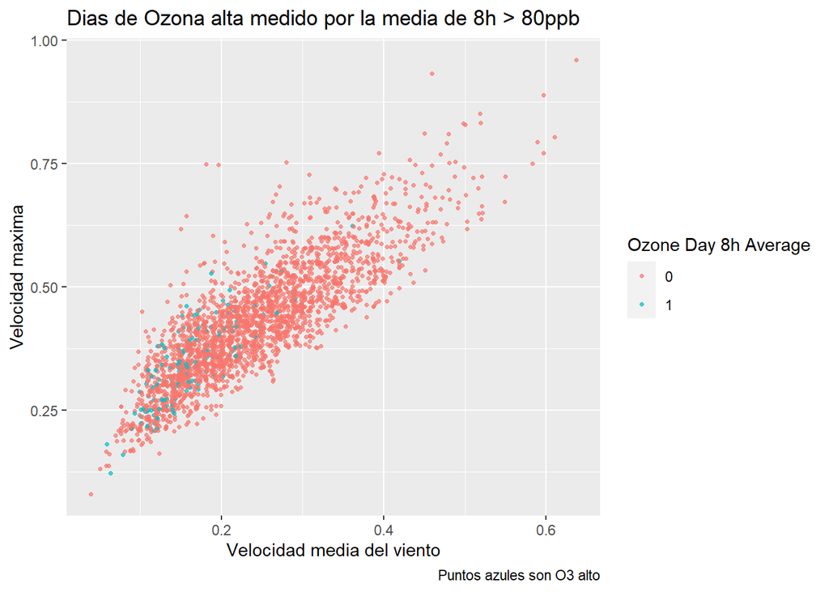

```r
ggplot(data=data_daily.vectors, aes(x=WSR_AV, y=WSR_PK, color=factor(Oz8h))) + geom_jitter(size=0.85, alpha=0.7) + xlab("Velocidad media del viento") +ylab("Velocidad maxima")+ labs(title='Dias de Ozona alta medido por la media de 8h > 80ppb', caption='Puntos azules son O3 alto', color= 'Ozone Day 8h Average')
```

Parece que tenemos mas días de Ozona cuando los vientos están mas calmas, generalmente, que cuadra con la intuición que la contaminación esta menor cuando el viento desplaza los precursores.

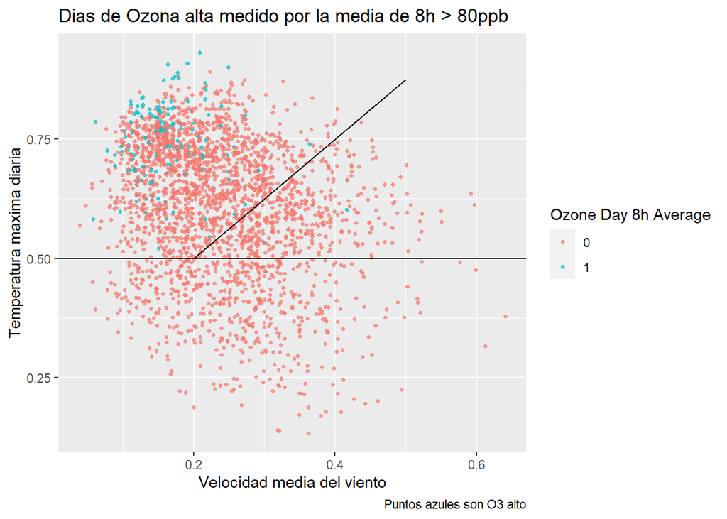

```r
ggplot(data=data_daily.vectors, aes(x=WSR_AV, y=T_PK, color=factor(Oz8h))) + geom_jitter(size=0.85, alpha=0.7) + xlab("Velocidad media del viento") +ylab("Temperatura maxima diaria")+ labs(title='Dias de Ozona alta medido por la media de 8h > 80ppb', caption='Puntos azules son O3 alto', color= 'Ozone Day 8h Average') +
  geom_hline(yintercept=0.50) + annotate("segment", x=0.2, y=0.5, xend = 0.5, yend = 0.875)
```

Se nota claramente que Ozona esta peor con temperaturas altas, y de hecho no tenemos ningún caso por debajo de la temperatura normalizada 0.50, como podemos ver con la linea horizontal. Además, solo se encuentre un punto de ozono a la derecha de la linea inclinada. Aparte de ese punto, todos se encuentran en la parte arriba-izquierdo del espacio. Eso quiere decir que el efecto positivo de temperaturas altas puede superar, hasta cierto nivel, el efecto inverso de vientos fuertes.

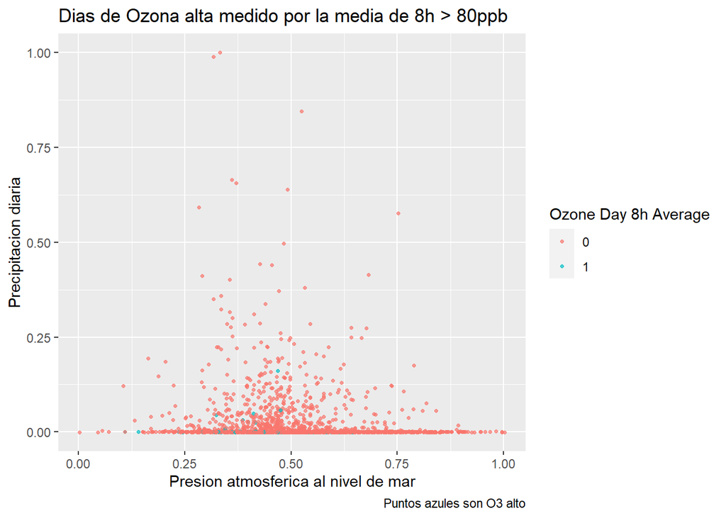

```r
ggplot(data=data_daily.vectors, aes(x=SLP, y=Precp, color=factor(Oz8h))) + geom_jitter(size=0.85, alpha=0.7) + xlab("Presion atmosferica al nivel de mar") +ylab("Precipitacion diaria")+ labs(title='Dias de Ozona alta medido por la media de 8h > 80ppb', caption='Puntos azules son O3 alto', color= 'Ozone Day 8h Average')
```

Ozona no aparece en los días con alta presión atmosférica, parece, y tampoco en los (pocos) días con alta precipitación. Como que alta presión atmosférica está normalmente asociado con temperaturas bajas, es cuadra con lo que hemos visto anteriormente, y con lo que entendemos del proceso de creación de ozono.

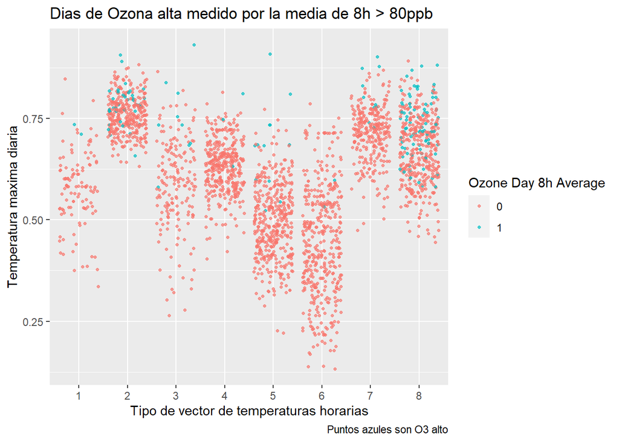

```r
ggplot(data=data_daily.vectors, aes(x=T.vect, y=T_PK, color=factor(Oz8h))) + geom_jitter(size=0.85, alpha=0.7) + xlab("Tipo de vector de temperaturas horarias") +ylab("Temperatura maxima diaria")+ labs(title='Dias de Ozona alta medido por la media de 8h > 80ppb', caption='Puntos azules son O3 alto', color= 'Ozone Day 8h Average')
```

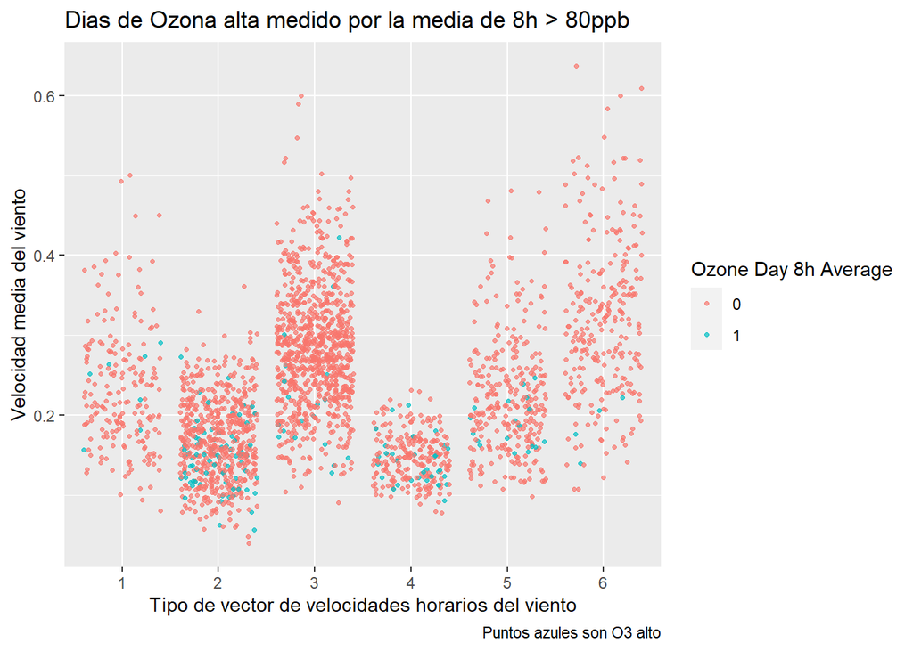

```r
ggplot(data=data_daily.vectors, aes(x=WSR.vect, y=WSR_AV, color=factor(Oz8h))) + geom_jitter(size=0.85, alpha=0.7) + xlab("Tipo de vector de velocidades horarios del viento") +ylab("Velocidad media del viento")+ labs(title='Dias de Ozona alta medido por la media de 8h > 80ppb', caption='Puntos azules son O3 alto', color= 'Ozone Day 8h Average')
```

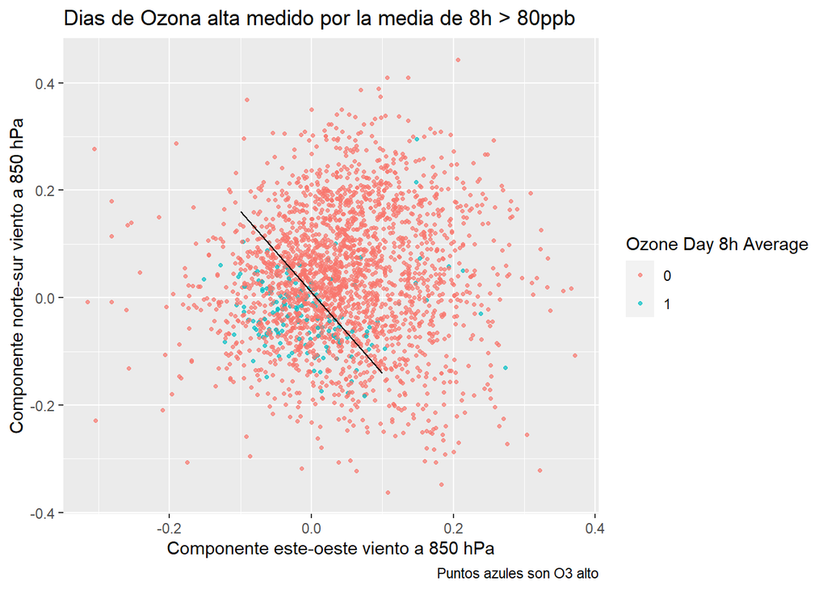

```r
ggplot(data=data_daily.vectors, aes(x=U85, y=V85, color=factor(Oz8h))) + geom_jitter(size=0.85, alpha=0.7) + xlab("Componente este-oeste viento a 850 hPa") +ylab("Componente norte-sur viento a 850 hPa")+ labs(title='Dias de Ozona alta medido por la media de 8h > 80ppb', caption='Puntos azules son O3 alto', color= 'Ozone Day 8h Average') + annotate("segment", x=-0.1, y=0.16, xend = 0.1, yend = -0.14)
```

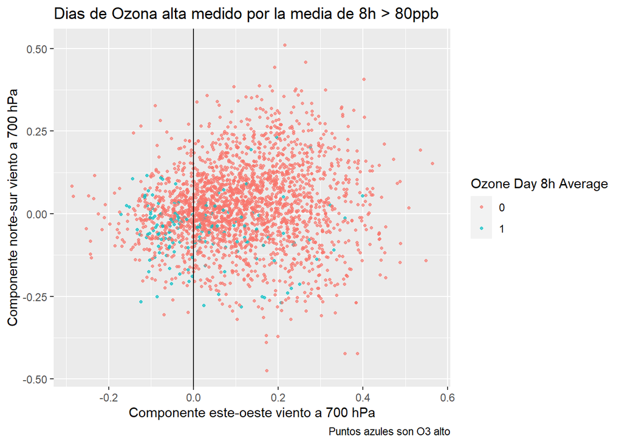

```r
ggplot(data=data_daily.vectors, aes(x=U70, y=V70, color=factor(Oz8h))) + geom_jitter(size=0.85, alpha=0.7) + xlab("Componente este-oeste viento a 700 hPa") +ylab("Componente norte-sur viento a 700 hPa")+ labs(title='Dias de Ozona alta medido por la media de 8h > 80ppb', caption='Puntos azules son O3 alto', color= 'Ozone Day 8h Average') +
  geom_vline(xintercept=0)
```

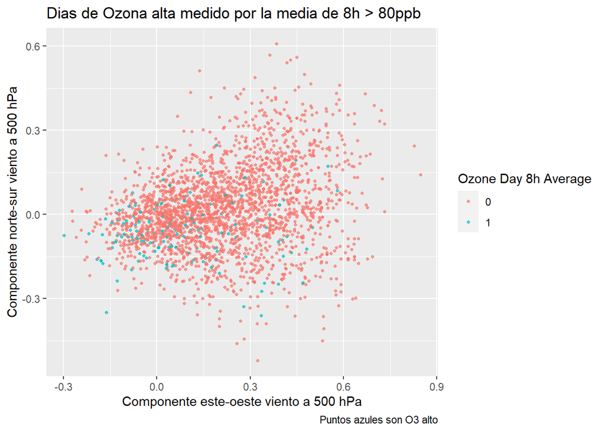

```r
ggplot(data=data_daily.vectors, aes(x=U50, y=V50, color=factor(Oz8h))) + geom_jitter(size=0.85, alpha=0.7) + xlab("Componente este-oeste viento a 500 hPa") +ylab("Componente norte-sur viento a 500 hPa")+ labs(title='Dias de Ozona alta medido por la media de 8h > 80ppb', caption='Puntos azules son O3 alto', color= 'Ozone Day 8h Average')
```

Los tres arriba son los vectores componentes del viento, a tres alturas distintas, empezando al mas bajo, donde hay presión de 850 hPA, luego el mediano a 700 hPA, y el mas alto a 500 hPA. Recuerda que la presión atmosférica disminuye con mas altura. Antes de crear los gráficos, pensaba que tener las dos lecturas, en dirección este-oeste y norte-sur, estaría sobrado, y que hubiera sido mejor combinar esos calculando la velocidad absoluta, independiente de la dirección.

Pero se puede apreciar unas cosas.

- Primero, se nota que los valores positivos del componente este-oeste tienen que ser el dominante al latitud donde se encuentra Houston, a 29 grados Norte [Ref. 6]. Eso parece justo al sur de la zona llamado “Latitudes del Caballo” (dicho como Lat 30-35 grados Norte), entrando en la zona de vientos alisios. Los alisios circulan en mayoría desde el noreste, mientras que en la zona del caballo, hay mezcla entre los alisios y los vientos desde el oeste que circulan a latitudes más hacía el norte. [Ref. 7]
- Esa mezcla también pasa en el vertical, en grandes flujos circulares llamados “Hadley cells” y “Ferrel cells” [Ref. 8], que, en los latitudes del caballo, están llevando un flujo de aire hacia el suelo desde la atmósfera. Ese flujo esta conocido como un factor que empeora la calidad de aire en esas latitudes por atrapar contaminación contra el suelo. [Ref. 8]. Entonces, los valores positivos serán viento del este, que cuadra con la descripción “Viento este-oeste”.
- Segundo, especialmente a la altura de 700 hPa, se puede ver una concentración de días de ozona cuando el viento este-oeste esta al revés, con valores negativos pequeños. Podremos suponer que pasa eso cuando hay un remolino a gran escala presionando contra el viento dominante desde el noreste. Estaría lógico, mirando los efectos físicos, de entender que tal situación podría causar un estancamiento de aire con contaminación, impidiendo su dispersión.
- A la altura de 850 hPa, casi vemos una linea a 45 grados a través del cero o cerca, con los días de Ozona abajo a la izquierda.
- En contra, a la altura mas alta, con vientos generalmente mas rápidas, vemos menos correlación con días de ozona, que es lógico como que hay menos conexión física con el aire al nivel del suelo, desde esa altura.

Ahora miramos otros datos a esas tres alturas distintas, la temperatura y humedad relativa. Pero, como que hemos quitado el dato RH70 por falta de relevancia, solo lo haremos a 850 hPA y 500 hPA, el más bajo y el más alto.

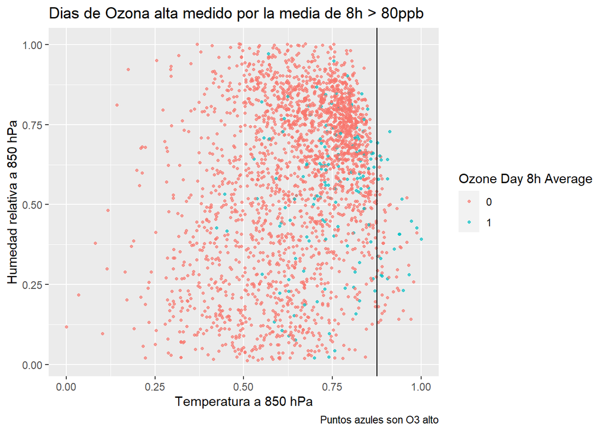

```r
ggplot(data=data_daily.vectors, aes(x=T85, y=RH85, color=factor(Oz8h))) + geom_jitter(size=0.85, alpha=0.7) + xlab("Temperatura a 850 hPa") +ylab("Humedad relativa a 850 hPa")+ labs(title='Dias de Ozona alta medido por la media de 8h > 80ppb', caption='Puntos azules son O3 alto', color= 'Ozone Day 8h Average') + geom_vline(xintercept=0.875)
```

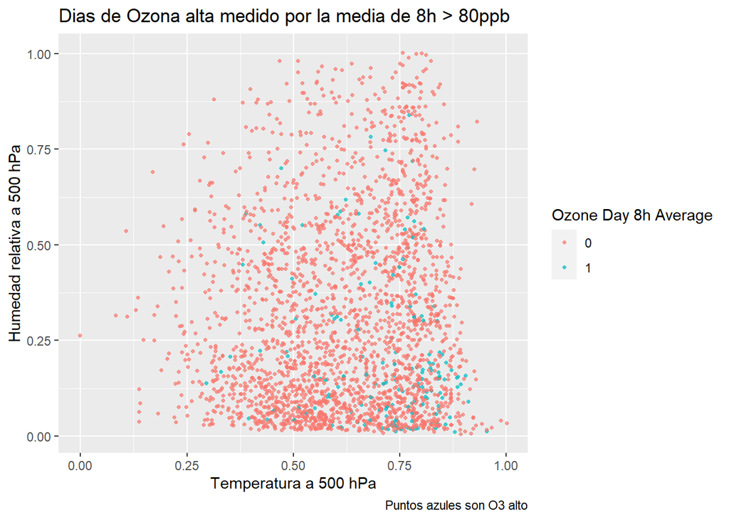

```r
#ggplot(data=data_daily.vectors, aes(x=T70, y=RH70, color=factor(Oz8h))) + geom_jitter(size=0.85, alpha=0.7) + xlab("Temperatura a 700 hPa") +ylab("Humedad relativa a 700 hPa")+ labs(title='Dias de Ozona alta medido por la media de 8h > 80ppb', caption='Puntos azules son O3 alto', color= 'Ozone Day 8h Average')

ggplot(data=data_daily.vectors, aes(x=T50, y=RH50, color=factor(Oz8h))) + geom_jitter(size=0.85, alpha=0.7) + xlab("Temperatura a 500 hPa") +ylab("Humedad relativa a 500 hPa")+ labs(title='Dias de Ozona alta medido por la media de 8h > 80ppb', caption='Puntos azules son O3 alto', color= 'Ozone Day 8h Average')
```

Se puede ver que hay más días de ozono a la derecha de cada gráfico, por decir a temperaturas relativamente altas, especialmente por la altura más baja de 850 hPa. De hecho, en la zona de temperaturas a 850 hPa, encima del valor normalizado de 0.875, parece haber una cantidad casi igual de días con ozona que de sin. Eso cuadra bien con la observación de correlación con altas temperaturas al nivel del suelo también.

No parecemos tener mucha correlación con humedad, pero es interesante ver como las niveles de humedad bajan fuertemente con altura.

## 4.2 Normalidad de datos

Hemos declarado anteriormente que los datos no son normales, pero sin apoyo de demostración, cosa que haremos aquí.

Un ejemplo, puede ser el atributo que más que ningún otro, podremos pensar que sería normal, no es normal. Falla una prueba Shapiro-Wilk, con un valor p minúscula, diciendo que es muy improbable que es normal. Posiblemente son más cerca a distribuciones gamma, pero tampoco he podido acertar pruebas confirmando eso.

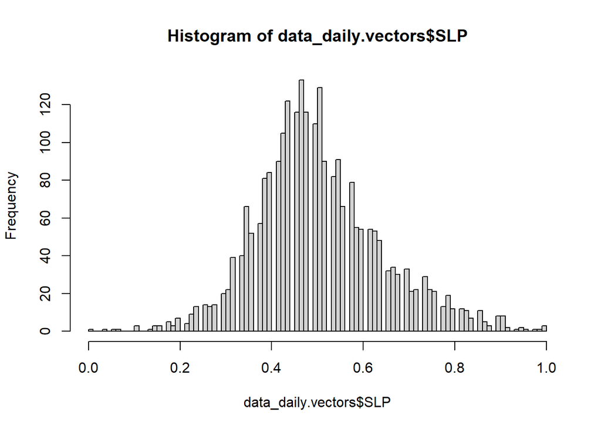

```r
# Histogram and Shapiro test of SLP
hist(data_daily.vectors$SLP, breaks=100)
```

```r
shapiro.test(data_daily.vectors$SLP)
```

```
##
##  Shapiro-Wilk normality test
##
## data:  data_daily.vectors$SLP
## W = 0.98094, p-value < 2.2e-16
```

Un segundo ejemplo negativo sera el RH85.

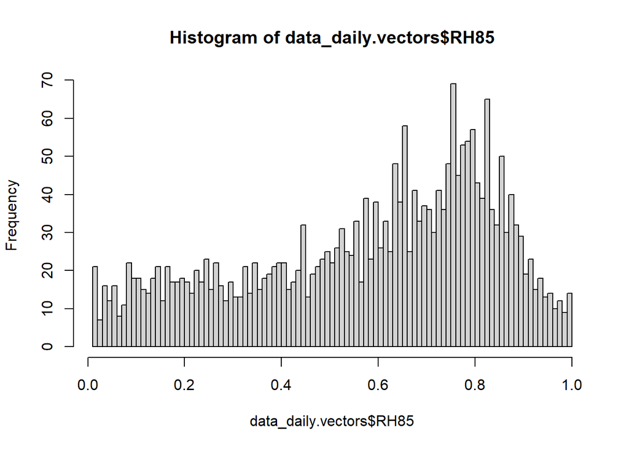

```r
# Histogram and Shapiro test of RH85
hist(data_daily.vectors$RH85, breaks=100)
```

```r
shapiro.test(data_daily.vectors$RH85)
```

```
##
##  Shapiro-Wilk normality test
##
## data:  data_daily.vectors$RH85
## W = 0.94133, p-value < 2.2e-16
```

## 4.3 Verificación de homocedasticidad

Aunque no contribuye directamente a los pasos posteriores de modelización, se puede verificar si las grupos de registros creados por las categorizaciones de los vectores, o de temperatura o del viento, dan grupos con varianzas parecidas o no. No tenemos motivos por antemano para suponer que darán varianzas diferentes.

Hay que usar una prueba Fligner-Killeen como que los datos no son normales, como visto anteriormente.

Normalmente, estaremos probando el atributo dependiente, pero aquí eso es el clase de Oz8h, un atributo no-númerico, y no hace sentido. En su lugar, demostraremos la prueba Fligner-Killeen con valores de T_PK (un atributo en principio independiente) según grupos por clasificación de T.vect, primero. En ese caso, cual clase de vector de temperatura tiene que ser relacionado con el valor máxima de temperatura, T_PK, y por tanto, estaría esperado que hay diferencias en varianzas entre grupos de registros dividos por T.vect.

```r
fligner.test(T_PK ~ T.vect, data=data_daily.vectors)
```

```
##
##  Fligner-Killeen test of homogeneity of variances
##
## data:  T_PK by T.vect
## Fligner-Killeen:med chi-squared = 391.62, df = 7, p-value < 2.2e-16
```

Efectivamente, tenemos un valor *p* muy pequeño y hay que rechazar el hipótesis de que las varianzas son iguales.

Ahora, cambiemos a mirar T_PK pero según grupos de vectores del viento. Estaría más normal que las varianzas sean iguales en ese caso.

```r
fligner.test(T_PK ~ WSR.vect, data=data_daily.vectors)
```

```
##
##  Fligner-Killeen test of homogeneity of variances
##
## data:  T_PK by WSR.vect
## Fligner-Killeen:med chi-squared = 63.563, df = 5, p-value = 2.225e-12
```

Pero, tampoco hay homocedasticidad aquí.

Un ejemplo más, probaremos dividiendo los registros según el clase de ozono alto por 8h, en lugar de por los clases de vectores. Eso nos analiza si hay varianza igual de datos según agrupamiento del atributo que queremos modelizar, una situación distinta de las dos pruebas anteriores. Como ejemplo, miraremos que varianza hay por el variable SLP.

```r
fligner.test(SLP ~ Oz8h, data=data_daily.vectors)
```

```
##
##  Fligner-Killeen test of homogeneity of variances
##
## data:  SLP by Oz8h
## Fligner-Killeen:med chi-squared = 17.952, df = 1, p-value = 2.266e-05
```

De nuevo, podemos ver que no tenemos homocedasticidad. Eso dicho, no tiene impacto en la aplicación posterior de algoritmos de modelización.

## 4.4 Análisis de los datos por modelos

Ahora empezaremos usando algoritmos de aprendizaje automático para buscar maneras de predecir días de ozono alto.

Como que tenemos dos clases distintas de ozono, lo de la media por 8h, y el de ozono alto para 1h, haremos un modelo cada vez para cada uno. Podrán tener éxito distinto como que no resultan de exactamente las mismas condiciones ni los mismos días.

### 4.4.1 Generación de reglas a partir de un arból de decisión, C5.0

Ahora usaremos arboles C5.0 para crear un juego de reglas. C5.0, siendo supervisado, necesita conjuntos de entrenamiento y de pruebas, y además, datos con secuencia aleatoria. Si estaremos manejando los conjuntos de entrenamiento y de pruebas manualmente, tendremos que barajar los registros, pero aquí usaremos los automatismos ofrecido en caret, controlado por trainControl, para especificar el uso de k=10 validación cruzada. También, tenemos que usar datos sin fecha, aunque se quedan numeradas por su fila.

Para encontrar la variación mejor adaptada del modelo C5.0, haremos una validación cruzada con 10 grupos, usando trainControl().

Además, como tenemos pocos casos de ozono, la prioridad no es la exactitud, sino la sensibilidad (*sensitivity*), entonces especificamos que la selección del modelo sea hecho basado en la máxima suya. Noto que no parece que train() está reaccionando al parámetro minCases, que se usa con C5.0 para reducir el sobreajuste del modelo. Veo que es una limitación conocida, y incluso he encontrado código para tratarlo [Ref. 12], aunque no probaré el código.

Nota: estamos bajando de 10 k-fold a 5 para reducir el tamaño de ciertos resultados, como que R-Studio está empezando a portarse malamente.

Nota: Aunque el argumento de priorizar la sensibilidad descrito anteriormente sigue valido, hemos visto en los resultados que estaría mejor priorizar Kappa, que nos dara un modelo mas robusto, considerando la extrema desigualidad de los clases en nuestros datos.

```r
train_control <- trainControl(method="cv",
                              number=5,
                              summaryFunction = multiClassSummary)

C5.0.train.8h <- train(Oz8h ~.,
                       data = subset(data_daily.vectors, select=-c(DATE, OzoneDay1hPeak)),
                       trControl = train_control,
                       method = "C5.0",
                       metric = "Kappa")
summary(C5.0.train.8h)
```

```
##
## Call:
## (function (x, y, trials = 1, rules = FALSE, weights = NULL, control
##  FALSE, noGlobalPruning = FALSE, CF = 0.25, minCases = 2, fuzzyThreshold
##  = FALSE, sample = 0, earlyStopping = TRUE, label = "outcome", seed = 2861L))
##
##
## C5.0 [Release 2.07 GPL Edition]      Tue Jan 04 19:41:45 2022
## -------------------------------
##
## Class specified by attribute `outcome'
##
## Read 2514 cases (29 attributes) from undefined.data
##
## -----  Trial 0:  -----
##
## Decision tree:
##
## U70 > -0.032:
## :...T_PK <= 0.68: 0 (1494/23)
## :   T_PK > 0.68:
## :   :...V70 > -0.0784: 0 (582/39)
## :       V70 <= -0.0784:
## :       :...T50 <= 0.5974026: 1 (12/3)
## :           T50 > 0.5974026: 0 (73/17)
## U70 <= -0.032:
## :...T_PK <= 0.764: 0 (224/20)
##     T_PK > 0.764:
##     :...RH85 > 0.68: 0 (47/7)
##         RH85 <= 0.68:
##         :...WSR_AV <= 0.17: 1 (40/7)
##             WSR_AV > 0.17:
##             :...T_PK <= 0.87: 0 (36/6)
##                 T_PK > 0.87: 1 (6/1)
##
## -----  Trial 1:  -----
##
## Decision tree:
##
## T.vect8 <= 0:
```

[output cut: 339 more lines]

```
##   51.83% RH85
##   50.32% U85
##   49.44% T70
##   49.32% U50
##   46.02% T50
##   43.79% RH50
##   34.41% WSR.vect5
##   33.53% T.vect5
##   29.87% T.vect7
##   27.76% WSR.vect6
##   20.60% WSR_PK
##   13.09% T.vect3
##
##
## Time: 0.5 secs
```

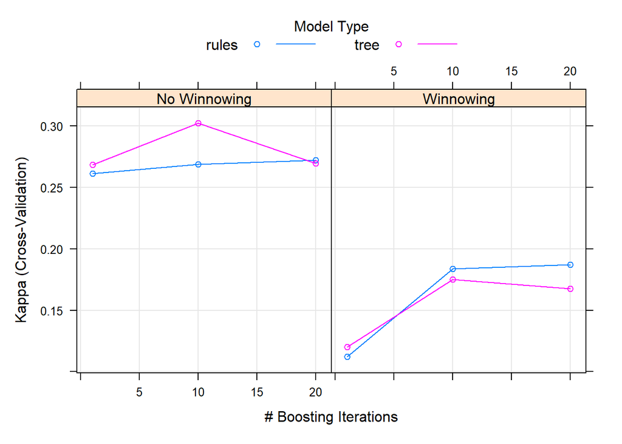

```r
plot(C5.0.train.8h)
```

```r
print(C5.0.train.8h)
```

```
## C5.0
##
## 2514 samples
##   18 predictor
##    2 classes: '0', '1'
##
## No pre-processing
## Resampling: Cross-Validated (5 fold)
## Summary of sample sizes: 2011, 2011, 2011, 2012, 2011
## Resampling results across tuning parameters:
##
##   model  winnow  trials  Accuracy   Kappa      F1         Sensitivity
##   rules  FALSE    1      0.9367540  0.2612525  0.9669032  0.9864119
##   rules  FALSE   10      0.9383460  0.2689112  0.9677599  0.9881104
##   rules  FALSE   20      0.9395389  0.2721495  0.9684084  0.9893843
##   rules   TRUE    1      0.9327755  0.1122202  0.9650046  0.9898089
##   rules   TRUE   10      0.9395373  0.1837171  0.9685631  0.9940552
##   rules   TRUE   20      0.9387420  0.1869574  0.9681151  0.9923567
##   tree   FALSE    1      0.9375500  0.2686055  0.9673274  0.9868365
##   tree   FALSE   10      0.9395428  0.3022387  0.9683398  0.9868365
##   tree   FALSE   20      0.9379500  0.2694948  0.9675422  0.9872611
##   tree    TRUE    1      0.9319802  0.1200417  0.9645494  0.9881104
##   tree    TRUE   10      0.9379468  0.1749032  0.9677053  0.9923567
##   tree    TRUE   20      0.9351611  0.1673692  0.9662035  0.9893843
##   Specificity  Pos_Pred_Value  Neg_Pred_Value  Precision  Recall
##   0.20120968   0.9481613       0.5211966       0.9481613  0.9864119
##   0.20141129   0.9482448       0.5693590       0.9482448  0.9881104
##   0.20161290   0.9483193       0.5812698       0.9483193  0.9893843
##   0.08810484   0.9414738       0.3319444       0.9414738  0.9898089
##   0.13185484   0.9443871       0.5678072       0.9443871  0.9940552
##   0.14455645   0.9451009       0.4456699       0.9451009  0.9923567
##   0.20766129   0.9485778       0.5119048       0.9485778  0.9868365
##   0.23991935   0.9505504       0.5424242       0.9505504  0.9868365
##   0.20806452   0.9486091       0.5236364       0.9486091  0.9872611
##   0.10060484   0.9421646       0.2945378       0.9421646  0.9881104
##   0.13205645   0.9443160       0.5017974       0.9443160  0.9923567
##   0.13225806   0.9441491       0.4195055       0.9441491  0.9893843
##   Detection_Rate  Balanced_Accuracy
##   0.9240256       0.5938108
##   0.9256168       0.5947608
##   0.9268089       0.5954986
##   0.9272065       0.5389569
##   0.9311850       0.5629550
##   0.9295938       0.5684566
##   0.9244232       0.5972489
##   0.9244240       0.6133779
##   0.9248216       0.5976628
##   0.9256160       0.5443576
##   0.9295938       0.5622066
##   0.9268073       0.5608212
##
## Kappa was used to select the optimal model using the largest value.
## The final values used for the model were trials = 10, model = tree and winnow
##  = FALSE.
```

Ahora vamos a confirmar las estadísticas de rendimiento por el modelo.

```r
confusionMatrix(C5.0.train.8h)
```

```
## Cross-Validated (5 fold) Confusion Matrix
##
## (entries are percentual average cell counts across resamples)
##
##           Reference
## Prediction    0    1
##          0 92.4  4.8
##          1  1.2  1.5
##
##  Accuracy (average) : 0.9395
```

```r
stats.best.C5.0 <- C5.0.train.8h$results[order(-C5.0.train.8h$results$Kappa), ][1, ]
stats.best.C5.0
```

```
##   model winnow trials  Accuracy     Kappa        F1 Sensitivity Specificity
## 2  tree  FALSE     10 0.9395428 0.3022387 0.9683398   0.9868365   0.2399194
##   Pos_Pred_Value Neg_Pred_Value Precision    Recall Detection_Rate
## 2      0.9505504      0.5424242 0.9505504 0.9868365       0.924424
##   Balanced_Accuracy  AccuracySD   KappaSD        F1SD SensitivitySD
## 2         0.6133779 0.006790373 0.1068201 0.003511777   0.003797992
##   SpecificitySD Pos_Pred_ValueSD Neg_Pred_ValueSD PrecisionSD    RecallSD
## 2    0.09723513      0.006496323        0.1018651 0.006496323 0.003797992
##   Detection_RateSD Balanced_AccuracySD
## 2      0.003700289          0.04819887
```

En las reglas podemos ver, por ejemplo, el uso de unos vectores:

- Rule 7: T.vect = 6
- Rule 10: T.vect in {5, 7}
- Rule 11: WSR.vect = 4
- Rule 12: T.vect in {4, 6}

Esos no cuadran con los que hemos notado en el análisis visual, exactamente (WSR vectors 1,2,4 y T vectors 3,5,6 nos parecían los idóneos para días de ozono.)

T_PK, en contra, tenía correlación alta con ozono, y lo vemos en todas la reglas donde sale ozono, como esperado.

### 4.4.2 Clasificación usando k-Nearest Neighbours

```r
train_control <- trainControl(method="cv",
                              number=10,
                              summaryFunction = multiClassSummary)

knn.train.8h <- train(Oz8h ~.,
                       data = subset(data_daily.vectors, select = -c(DATE, OzoneDay1hPeak)),
                       trControl = train_control,
                       method = "knn",
                       tuneLength = 20,
                       metric = "Sensitivity")
knn.train.8h
```

```
## k-Nearest Neighbors
##
## 2514 samples
##   18 predictor
##    2 classes: '0', '1'
##
## No pre-processing
## Resampling: Cross-Validated (10 fold)
## Summary of sample sizes: 2262, 2262, 2263, 2263, 2263, 2262, ...
## Resampling results across tuning parameters:
##
##   k   Accuracy   Kappa       F1         Sensitivity  Specificity
##    5  0.9323814  0.18313501  0.9646590  0.9855554    0.1450000
##    7  0.9355655  0.18298670  0.9664041  0.9893761    0.1391667
##    9  0.9379433  0.18473837  0.9676959  0.9923512    0.1316667
##   11  0.9367576  0.14921568  0.9671180  0.9927840    0.1066667
##   13  0.9371607  0.12550804  0.9673745  0.9944843    0.0875000
##   15  0.9375559  0.10417636  0.9676251  0.9961828    0.0687500
##   17  0.9371559  0.06886801  0.9674640  0.9974540    0.0437500
##   19  0.9375528  0.05272599  0.9677033  0.9987270    0.0312500
##   21  0.9375528  0.03254406  0.9677304  0.9995763    0.0187500
##   23  0.9371544  0.01109799  0.9675444  1.0000000    0.0062500
##   25  0.9375512  0.02219865  0.9677431  1.0000000    0.0125000
##   27  0.9367560  0.00000000  0.9673450  1.0000000    0.0000000
##   29  0.9367560  0.00000000  0.9673450  1.0000000    0.0000000
##   31  0.9367560  0.00000000  0.9673450  1.0000000    0.0000000
##   33  0.9367560  0.00000000  0.9673450  1.0000000    0.0000000
##   35  0.9367560  0.00000000  0.9673450  1.0000000    0.0000000
##   37  0.9367560  0.00000000  0.9673450  1.0000000    0.0000000
##   39  0.9367560  0.00000000  0.9673450  1.0000000    0.0000000
##   41  0.9367560  0.00000000  0.9673450  1.0000000    0.0000000
##   43  0.9367560  0.00000000  0.9673450  1.0000000    0.0000000
##   Pos_Pred_Value  Neg_Pred_Value  Precision  Recall     Detection_Rate
##   0.9446700       0.4212013       0.9446700  0.9855554  0.9232307
##   0.9445193       0.4783333       0.9445193  0.9893761  0.9268053
##   0.9442660       0.5450000       0.9442660  0.9923512  0.9295941
##   0.9427718       0.4941667       0.9427718  0.9927840  0.9299989
##   0.9417254       0.5166667       0.9417254  0.9944843  0.9315909
##   0.9406747       0.6062500       0.9406747  0.9961828  0.9331814
##   0.9392338       0.5714286       0.9392338  0.9974540  0.9343718
```

[output cut: 22 more lines]

```
##   0.5091631
##   0.5031250
##   0.5062500
##   0.5000000
##   0.5000000
##   0.5000000
##   0.5000000
##   0.5000000
##   0.5000000
##   0.5000000
##   0.5000000
##   0.5000000
##
## Sensitivity was used to select the optimal model using the largest value.
## The final value used for the model was k = 43.
```

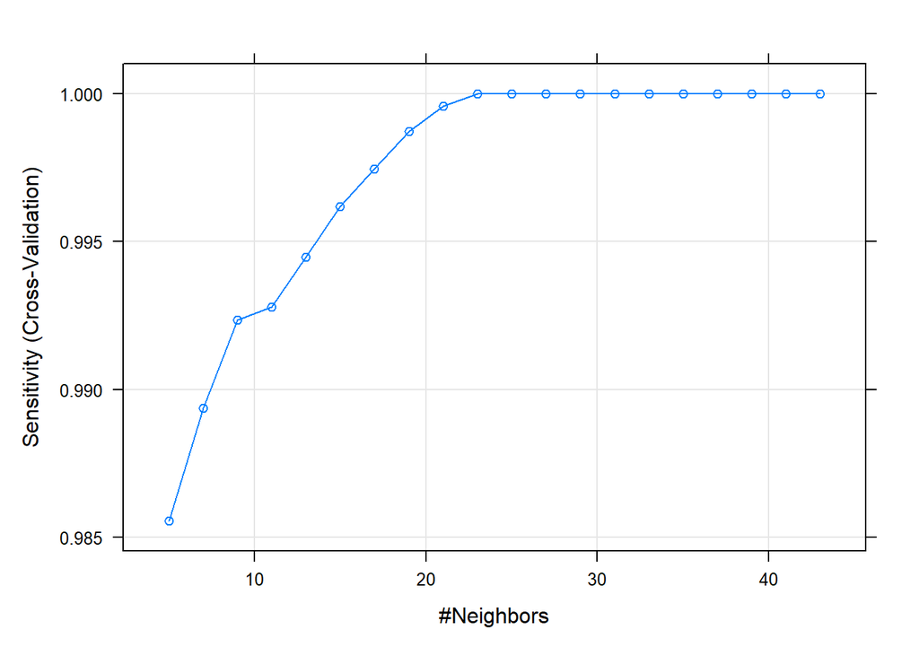

```r
plot(knn.train.8h)
```

Podemos ver que el rango elegido automáticamente de valores k acaba siendo demasiado gruesa para detectar los días de ozono, y acaba dando modelos inválidos después de k=25. Tenemos que investigar rangos más bajas de valores k.

```r
knn.train.8hbis <- train(Oz8h ~.,
                       data = subset(data_daily.vectors, select = -c(DATE, OzoneDay1hPeak)),
                       trControl = train_control,
                       method = "knn",
                       tuneGrid = data.frame(k=seq(3,23,by=2)),
                       metric = "Sensitivity")
```

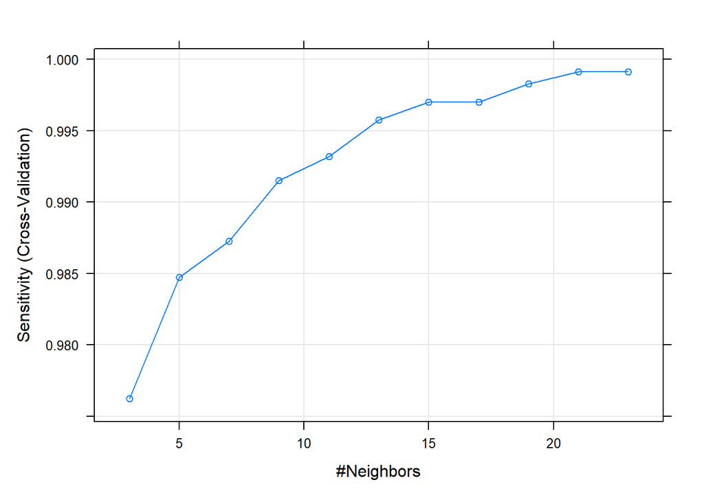

```r
plot(knn.train.8hbis)
```

```r
print(knn.train.8hbis)
```

```
## k-Nearest Neighbors
##
## 2514 samples
##   18 predictor
##    2 classes: '0', '1'
##
## No pre-processing
## Resampling: Cross-Validated (10 fold)
## Summary of sample sizes: 2263, 2262, 2263, 2263, 2262, 2262, ...
## Resampling results across tuning parameters:
##
##   k   Accuracy   Kappa         F1         Sensitivity  Specificity
##    3  0.9272134   0.222960227  0.9617132  0.9762207    0.20166667
##    5  0.9319879   0.188528185  0.9644382  0.9847205    0.15125000
##    7  0.9335752   0.181308603  0.9653260  0.9872647    0.13833333
##    9  0.9343657   0.125243642  0.9658699  0.9915038    0.08833333
##   11  0.9355578   0.115074739  0.9665257  0.9932005    0.08166667
##   13  0.9363562   0.085716647  0.9670083  0.9957519    0.05625000
##   15  0.9355578   0.038247764  0.9666486  0.9970249    0.02500000
##   17  0.9355609   0.036765454  0.9666503  0.9970267    0.02500000
##   19  0.9359562   0.018747138  0.9668896  0.9982997    0.01250000
##   21  0.9363546   0.009663748  0.9671160  0.9991489    0.00625000
##   23  0.9359578  -0.001436911  0.9669174  0.9991489    0.00000000
##   Pos_Pred_Value  Neg_Pred_Value  Precision  Recall     Detection_Rate
##   0.9476697       0.3692605       0.9476697  0.9762207  0.9144833
##   0.9450079       0.4192063       0.9450079  0.9847205  0.9224420
##   0.9443644       0.4657143       0.9443644  0.9872647  0.9248261
##   0.9415343       0.4116667       0.9415343  0.9915038  0.9287975
##   0.9412670       0.4333333       0.9412670  0.9932005  0.9303880
##   0.9398848       0.5000000       0.9398848  0.9957519  0.9327768
##   0.9380727       0.4285714       0.9380727  0.9970249  0.9339689
##   0.9380785       0.3666667       0.9380785  0.9970267  0.9339705
##   0.9374002       0.3750000       0.9374002  0.9982997  0.9351625
##   0.9370765       0.5000000       0.9370765  0.9991489  0.9359578
##   0.9367034       0.0000000       0.9367034  0.9991489  0.9359578
##   Balanced_Accuracy
##   0.5889437
##   0.5679853
##   0.5627990
##   0.5399186
##   0.5374336
##   0.5260009
##   0.5110124
##   0.5110133
##   0.5053998
##   0.5026995
##   0.4995745
##
## Sensitivity was used to select the optimal model using the largest value.
## The final value used for the model was k = 23.
```

Vemos que Cohen’s kappa y Specificity caen rápidamente desde k=3. Por kappa, eso quiere decir que los negativos falsos y positivos falsos están creciendo rápidamente. Cuando a specificity, quiere decir que los positivos falsos están creciendo rápidamente. En ese contexto, un falso positivo es un día clasificado como de ozono cuando no es en la realidad, por decir, da un estado de alarma sin ser correcto. Notamos que en [Ref. 13] dicen que Kappa es más útil cuando hay proporciones de clases muy desigual, cosa que existe aqui en nuestros datos, con aprox 150 casos de ozono 8h en 2500 registros. Entonces mejor que le prestamos atención.

El hecho que empezamos con valores bajas de kappa y specificity ya con k=3, y no mejoran, sugiere que estamos mejor quedando con k=3. Entonces calculamos de nuevo el modelo, con k fijo a ese valor.

```r
knn.train.8h.k3 <- train(Oz8h ~.,
                       data = subset(data_daily.vectors, select = -c(DATE, OzoneDay1hPeak)),
                       trControl = train_control,
                       method = "knn",
                       tuneGrid = data.frame(k=3),
                       metric = "Sensitivity")
```

```r
print(knn.train.8h.k3)
```

```
## k-Nearest Neighbors
##
## 2514 samples
##   18 predictor
##    2 classes: '0', '1'
##
## No pre-processing
## Resampling: Cross-Validated (10 fold)
## Summary of sample sizes: 2263, 2262, 2263, 2262, 2262, 2262, ...
## Resampling results:
##
##   Accuracy  Kappa      F1         Sensitivity  Specificity  Pos_Pred_Value
##   0.92841   0.1996331  0.9624327  0.9791958    0.1758333    0.9462807
##   Neg_Pred_Value  Precision  Recall     Detection_Rate  Balanced_Accuracy
##   0.3637879       0.9462807  0.9791958  0.9172704       0.5775146
##
## Tuning parameter 'k' was held constant at a value of 3
```

```r
knn.train.8h.k3$finalModel
```

```
## 3-nearest neighbor model
## Training set outcome distribution:
##
##    0    1
## 2355  159
```

Hacemos ahora una matriz de confusión como con C5.0.

```r
confusionMatrix(knn.train.8h.k3)
```

```
## Cross-Validated (10 fold) Confusion Matrix
##
## (entries are percentual average cell counts across resamples)
##
##           Reference
## Prediction    0    1
##          0 91.7  5.2
##          1  1.9  1.1
##
##  Accuracy (average) : 0.9284
```

Como que el modelo es de clustering, no se puede mostrar como las reglas de C5.0, y tampoco como se puede ver los modelos de redes neurales.

### 4.4.3 Clasificación usando Neural Networks

Procedemos por un método análogo al anterior. Estamos quitando el echo de la consola por evitar un listado muy largo que no usaremos.

```r
train_control <- trainControl(method="cv",
                              number=5,
                              summaryFunction = multiClassSummary)

nn.train.8h <- train(Oz8h ~.,
                       data = subset(data_daily.vectors, select = -c(DATE, OzoneDay1hPeak)),
                       trControl = train_control,
                       method = "nnet",
                       tuneGrid = data.frame(size = seq(2,8,by=1), decay = 0),
                       metric = "Sensitivity")
nn.train.8h
```

```
## Neural Network
##
## 2514 samples
##   18 predictor
##    2 classes: '0', '1'
##
## No pre-processing
## Resampling: Cross-Validated (5 fold)
## Summary of sample sizes: 2011, 2011, 2012, 2011, 2011
## Resampling results across tuning parameters:
##
##   size  Accuracy   Kappa      F1         Sensitivity  Specificity
##   2     0.9252240  0.2054368  0.9604319  0.9732484    0.2137097
##   3     0.9113051  0.2721644  0.9519644  0.9469214    0.3814516
##   4     0.9311866  0.2791820  0.9637500  0.9770701    0.2512097
##   5     0.9260152  0.3054727  0.9606726  0.9656051    0.3385081
##   6     0.9244224  0.2147005  0.9601865  0.9732484    0.2018145
##   7     0.9188566  0.2524683  0.9569055  0.9626327    0.2699597
##   8     0.9204439  0.1774385  0.9580036  0.9707006    0.1768145
##   Pos_Pred_Value  Neg_Pred_Value  Precision  Recall     Detection_Rate
##   0.9485659       0.3971154       0.9485659  0.9732484  0.9117003
##   0.9585845       0.3517287       0.9585845  0.9469214  0.8870498
##   0.9508718       0.4430468       0.9508718  0.9770701  0.9152773
##   0.9562158       0.3944269       0.9562158  0.9656051  0.9045401
##   0.9475213       0.3520879       0.9475213  0.9732484  0.9116916
##   0.9513518       0.3360960       0.9513518  0.9626327  0.9017544
##   0.9458683       0.3656043       0.9458683  0.9707006  0.9093035
##   Balanced_Accuracy
##   0.5934790
##   0.6641865
##   0.6141399
##   0.6520566
##   0.5875315
##   0.6162962
##   0.5737576
##
## Tuning parameter 'decay' was held constant at a value of 0
## Sensitivity was used to select the optimal model using the largest value.
## The final values used for the model were size = 4 and decay = 0.
```

```r
nn.train.8h.size3 <- train(Oz8h ~.,
                       data = subset(data_daily.vectors, select = -c(DATE, OzoneDay1hPeak)),
                       trControl = train_control,
                       method = "nnet",
                       tuneGrid = data.frame(size = 3, decay = 0),
                       metric = "Sensitivity")
nn.train.8h.size3
```

```
## Neural Network
##
## 2514 samples
##   18 predictor
##    2 classes: '0', '1'
##
## No pre-processing
## Resampling: Cross-Validated (5 fold)
## Summary of sample sizes: 2012, 2011, 2011, 2011, 2011
## Resampling results:
##
##   Accuracy   Kappa      F1         Sensitivity  Specificity  Pos_Pred_Value
##   0.9232351  0.2174519  0.9592831  0.9685775    0.2506048    0.9507661
##   Neg_Pred_Value  Precision  Recall     Detection_Rate  Balanced_Accuracy
##   0.3693356       0.9507661  0.9685775  0.9073281       0.6095912
##
## Tuning parameter 'size' was held constant at a value of 3
## Tuning
##  parameter 'decay' was held constant at a value of 0
```

Ahora podemos (de cierto modo) visualizar la red neuronal.

```r
summary(nn.train.8h.size3)
```

```
## a 28-3-1 network with 91 weights
## options were - entropy fitting
##   b->h1  i1->h1  i2->h1  i3->h1  i4->h1  i5->h1  i6->h1  i7->h1  i8->h1  i9->h1
##  278.75 -121.99  267.21 -314.12   10.24   27.77   36.92  107.10  -50.57   35.34
## i10->h1 i11->h1 i12->h1 i13->h1 i14->h1 i15->h1 i16->h1 i17->h1 i18->h1 i19->h1
## -107.44  111.30   50.34  -57.96   58.36   40.65  -29.41   10.28   15.89   12.88
## i20->h1 i21->h1 i22->h1 i23->h1 i24->h1 i25->h1 i26->h1 i27->h1 i28->h1
##    4.67   17.18   17.64 -125.09 -151.07 -133.81 -151.04 -118.22 -157.77
##   b->h2  i1->h2  i2->h2  i3->h2  i4->h2  i5->h2  i6->h2  i7->h2  i8->h2  i9->h2
## -328.06  -48.23 -246.37 1374.06  -90.14 -362.14 -588.27  688.58  540.88  419.07
## i10->h2 i11->h2 i12->h2 i13->h2 i14->h2 i15->h2 i16->h2 i17->h2 i18->h2 i19->h2
## -200.70 -845.95  391.50  -24.92  299.08 -755.16  -71.84   26.97  -46.39  170.18
## i20->h2 i21->h2 i22->h2 i23->h2 i24->h2 i25->h2 i26->h2 i27->h2 i28->h2
##  -91.55 -866.93  746.51  127.80  264.10  244.98  -67.71  -73.19 -239.57
##   b->h3  i1->h3  i2->h3  i3->h3  i4->h3  i5->h3  i6->h3  i7->h3  i8->h3  i9->h3
##  378.77  -97.50  526.81 -885.35  168.78   72.16  878.54  544.26   67.08   69.50
## i10->h3 i11->h3 i12->h3 i13->h3 i14->h3 i15->h3 i16->h3 i17->h3 i18->h3 i19->h3
##  -82.25  -11.08  156.04 -453.34   91.87 -108.90  524.66  -50.52  -53.45  -15.31
## i20->h3 i21->h3 i22->h3 i23->h3 i24->h3 i25->h3 i26->h3 i27->h3 i28->h3
##  -80.42 -259.72   80.93  -51.16  125.38   47.51  -91.64  -34.02 -390.34
##    b->o   h1->o   h2->o   h3->o
##   -0.05   -4.01    3.58  -76.71
```

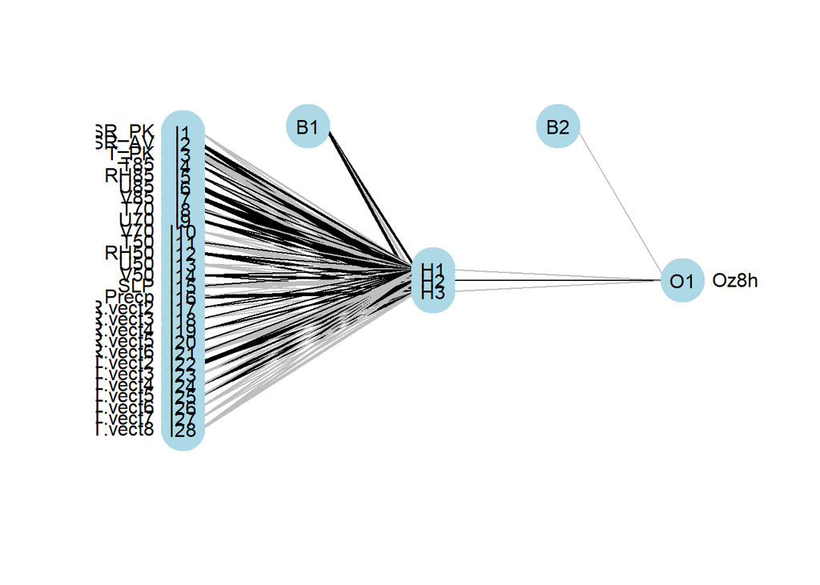

```r
plotnet(nn.train.8h.size3)#$finalModel)
```

Finalmente, la matriz de confusión:

Directamente del objecto *train*, que nos da el rendimiento, tomando en cuenta la validación cruzada 5-fold, hecho durante la producción del modelo:

```r
confusionMatrix(nn.train.8h.size3, )
```

```
## Cross-Validated (5 fold) Confusion Matrix
##
## (entries are percentual average cell counts across resamples)
##
##           Reference
## Prediction    0    1
##          0 90.7  4.7
##          1  2.9  1.6
##
##  Accuracy (average) : 0.9232
```

```r
nn.train.8h.size3$results
```

```
##   size decay  Accuracy     Kappa        F1 Sensitivity Specificity
## 1    3     0 0.9232351 0.2174519 0.9592831   0.9685775   0.2506048
##   Pos_Pred_Value Neg_Pred_Value Precision    Recall Detection_Rate
## 1      0.9507661      0.3693356 0.9507661 0.9685775      0.9073281
##   Balanced_Accuracy AccuracySD   KappaSD       F1SD SensitivitySD SpecificitySD
## 1         0.6095912 0.01385822 0.1467341 0.00817323    0.02757634     0.2007309
##   Pos_Pred_ValueSD Neg_Pred_ValueSD PrecisionSD   RecallSD Detection_RateSD
## 1       0.01107612       0.05014757  0.01107612 0.02757634       0.02621667
##   Balanced_AccuracySD
## 1          0.08685297
```

# 5 Resultados y Conclusiones

Tras ese esfuerzo extendido de procesamiento de los datos, hemos podido proceder al análisis de los datos, primero visualmente con la ayuda de gráficos, primariamente *scatterplots*, y después pasando por modelos de aprendizaje automatizado, con la meta de producir modelos predictivos para ayudar a avisar cuando hay un día con ozono alto.

Los modelos, al final, solo han sido creado para predecir los días de ozono alto medida por 8 horas - la otra clase de ozono agudo por una hora no ha sido estudiado con modelos por falta de tiempo.

## 5.1 Comparación de rendimiento de modelos

| Tipo de medida | Modelo Arbol C5.0 | Modelo kNN | Modelo Red Neural |
| --- | --- | --- | --- |
| Exactitud (Accuracy) | 0.9395428 | 0.92841 | 0.9232351 |
| Cohen’s Kappa | 0.3022387 | 0.1996331 | 0.2174519 |
| Sensibilidad (Sensitivity) | 0.9868365 | 0.9791958 | 0.9685775 |
| Especificidad (Specificity) | 0.2399194 | 0.1758333 | 0.2506048 |

Dos medidas que hemos visto más importante son Kappa y Sensitivity, que son mejor adaptados a nuestra situación de casos positivos escasos. La exactitud puede parecer artificialmente alta con nuestros datos, como que una regla sencilla de clasificar todos los registros como sin ozono alto, saldría con exactitud de aproximadamente (2500-150)/2500 o 94%. Por tanto, hay que evaluar según otras medidas.

## 5.2 Visualización de clasificación

Añadiremos dos columnas más a los datos por ese motivo, el primero la predicción de clase dada por el modelo, y el segundo un calculo basado en la columna de la clase verdadero y la clase de predicción. En el *scatterplot*, veremos los puntos clasificados por color:

- un color para los días sin ozono, verdadero, y sin predicción de ozono
- un color para los días con ozono, pero sin predicción de ozono (también descrito como Falsos Negativos)
- un color para los días sin ozono, pero con predicción de ozono (los Positivos Falsos)
- un color para los días con ozono, con predicción de ozono (los Positivos Verdaderos)

```r
data_demo_pred <- data_daily.vectors

knn.predict.on.fulldata <- predict(knn.train.8h.k3,  subset(data_daily.vectors, select=-c(DATE, OzoneDay1hPeak, Oz8h)))

data_demo_pred <- as.data.frame(cbind(data_demo_pred, knn.predict.on.fulldata))
```

```r
composite <- as.numeric(data_demo_pred$Oz8h) + 2*as.numeric(data_demo_pred$knn.predict.on.fulldata)
#table(composite)
```

```r
data_demo_pred$composite <- factor(composite, levels = c("3", "4", "5", "6"), labels = c("Negativo verdadero", "Negativo falso", "Positivo falso", "Positivo verdadero"))
#data_demo_pred <- as.data.frame(cbind(data_demo_pred, composite = as.factor(composite, labels())))
str(data_demo_pred)
```

```
## 'data.frame':    2514 obs. of  23 variables:
##  $ DATE                   : Date, format: "1998-01-01" "1998-01-02" ...
##  $ WSR_PK                 : num  0.55 0.55 0.56 0.47 0.37 0.68 0.7 0.68 0.41 0.33 ...
##  $ WSR_AV                 : num  0.31 0.34 0.35 0.32 0.23 0.32 0.52 0.39 0.21 0.17 ...
##  $ T_PK                   : num  0.482 0.548 0.544 0.492 0.62 0.492 0.416 0.398 0.44 0.546 ...
##  $ T85                    : num  0.437 0.509 0.509 0.538 0.671 ...
##  $ RH85                   : num  0.11 0.25 0.56 0.89 0.78 0.68 0.98 0.73 0.38 0.23 ...
##  $ U85                    : num  0.0766 -0.0082 0.0178 -0.0068 0.0412 ...
##  $ V85                    : num  0.0028 0.1906 0.2034 0.1716 0.1902 ...
##  $ T70                    : num  0.291 0.295 0.414 0.494 0.602 ...
##  $ U70                    : num  0.1436 0.1648 0.076 0.0834 0.118 ...
##  $ V70                    : num  0.0024 0.146 0.0884 0.1622 0.0386 ...
##  $ T50                    : num  0.403 0.446 0.385 0.346 0.593 ...
##  $ RH50                   : num  0.15 0.48 0.6 0.49 0.5 0.09 0.84 0.2 0.51 0.08 ...
##  $ U50                    : num  0.213 0.168 0.139 0.175 0.261 ...
##  $ V50                    : num  -0.0312 0.0768 0.196 0.2108 0.183 ...
##  $ SLP                    : num  0.947 0.8 0.693 0.587 0.627 ...
##  $ Precp                  : num  0 0 0 0.1007 0.0281 ...
##  $ OzoneDay1hPeak         : Factor w/ 2 levels "0","1": 1 1 1 1 1 1 1 1 1 1 ...
##  $ Oz8h                   : Factor w/ 2 levels "0","1": 1 1 1 1 1 1 1 1 1 1 ...
##  $ WSR.vect               : Factor w/ 6 levels "1","2","3","4",..: 3 3 3 6 3 6 6 1 2 2 ...
##  $ T.vect                 : Factor w/ 8 levels "1","2","3","4",..: 5 6 4 6 6 3 1 5 5 4 ...
##  $ knn.predict.on.fulldata: Factor w/ 2 levels "0","1": 1 1 1 1 1 1 1 1 1 1 ...
##  $ composite              : Factor w/ 4 levels "Negativo verdadero",..: 1 1 1 1 1 1 1 1 1 1 ...
```

```r
table(data_demo_pred$composite)
```

```
##
## Negativo verdadero     Negativo falso     Positivo falso Positivo verdadero
##               2335                 87                 20                 72
```

Ahora podemos hacer los dos *scatterplots*. Para ayudar a apercebir los puntos de interés, donde o el modelo o la realidad dice que hay ozono, hemos configurado la transparencia de los puntos para que sean menos transparentes lo más que suban la escala de negativo falso - positivo falso - positivo verdadero. Aparte de la modificación para incorporar la visualización de los NV/NF/PF/PV, son iguales a los gráficos análogos en el apartado del análisis visual.

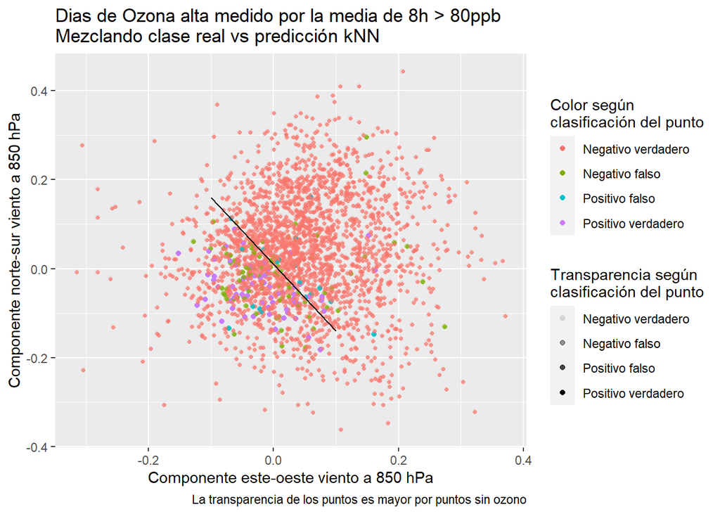

```r
ggplot(data=data_demo_pred, aes(x=U85, y=V85, color=composite, alpha=composite)) + geom_point() + geom_jitter(size=0.85, alpha=0.7) + xlab("Componente este-oeste viento a 850 hPa") +ylab("Componente norte-sur viento a 850 hPa")+ labs(title='Dias de Ozona alta medido por la media de 8h > 80ppb\nMezclando clase real vs predicción kNN', caption='La transparencia de los puntos es mayor por puntos sin ozono', alpha = "Transparencia según\nclasificación del punto", color= 'Color según\nclasificación del punto') + annotate("segment", x=-0.1, y=0.16, xend = 0.1, yend = -0.14)
```

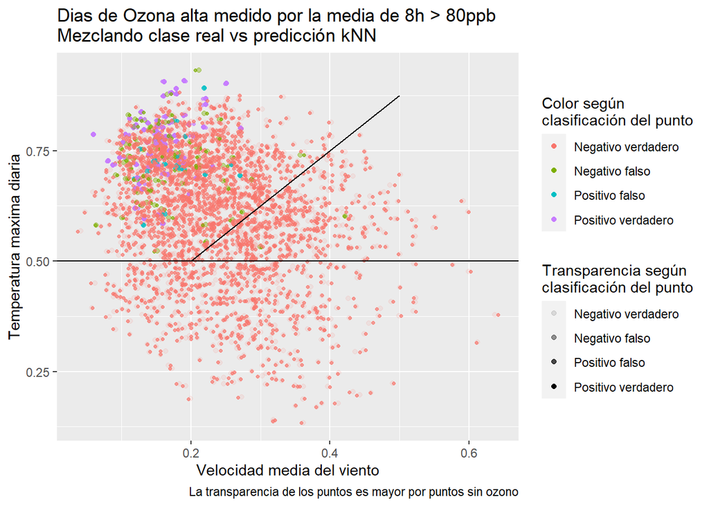

```r
ggplot(data=data_demo_pred, aes(x=WSR_AV, y=T_PK, color=composite, alpha=composite)) + geom_point(position="jitter") + geom_jitter(size=0.85, alpha=0.7) + xlab("Velocidad media del viento") +ylab("Temperatura maxima diaria")+ labs(title='Dias de Ozona alta medido por la media de 8h > 80ppb\nMezclando clase real vs predicción kNN', caption='La transparencia de los puntos es mayor por puntos sin ozono', alpha = "Transparencia según\nclasificación del punto", color= 'Color según\nclasificación del punto') + geom_hline(yintercept=0.50) + annotate("segment", x=0.2, y=0.5, xend = 0.5, yend = 0.875)
```

Entonces, nos quedamos con tres modelos automatizados que, en principio, podrían ayudar a predecir condiciones en que hay ozono de niveles contaminantes, en Houston. Se podría, en principio, ser extendido a otros lugares, aunque condiciones como las direcciones de los vientos, y niveles absolutos de temperaturas y humedad relativa, podrían necesitar un traslado para adaptarse al nuevo localidad.

# 6 Bibliografía

1. https://www.science.org/content/article/here-are-some-world-s-worst-cities-air-quality
2. https://en.wikipedia.org/wiki/Ozone
3. Kun Zhang and Wei Fan, “Forecasting Skewed Biased Stochastic Ozone Days: analyses, solutions and beyond” 2006
4. [National Oceanic and Atmospheric Administration’s Glossary https://w1.weather.gov/glossary/index.php](https://w1.weather.gov/glossary/index.php)
5. [Geopotential Height wikipedia https://en.wikipedia.org/wiki/Geopotential_height](https://en.wikipedia.org/wiki/Geopotential_height)
6. [Dew Point wikipedia https://en.wikipedia.org/wiki/Dew_point](https://en.wikipedia.org/wiki/Dew_point)
7. [Houston wikipedia, https://en.wikipedia.org/wiki/Houston](https://en.wikipedia.org/wiki/Houston)
8. [Prevailing Winds wikipedia, https://en.wikipedia.org/wiki/Prevailing_winds](https://en.wikipedia.org/wiki/Prevailing_winds)
9. [Horse Latitudes wikipedia, https://en.wikipedia.org/wiki/Horse_latitudes](https://en.wikipedia.org/wiki/Horse_latitudes)
10. [Atmospheric pressure wikipedia, https://en.wikipedia.org/wiki/Atmospheric_pressure](https://en.wikipedia.org/wiki/Atmospheric_pressure)
11. [Climate of Houston wikipedia, https://en.wikipedia.org/wiki/Climate_of_Houston](https://en.wikipedia.org/wiki/Climate_of_Houston)
12. [R, caret, and Parameter Tuning C5.0, https://www.euclidean.com/machine-learning-in-practice/2015/6/12/r-caret-and-parameter-tuning-c50](https://www.euclidean.com/machine-learning-in-practice/2015/6/12/r-caret-and-parameter-tuning-c50)
13. [Machine Learning Evaluation Metrics in R, https://machinelearningmastery.com/machine-learning-evaluation-metrics-in-r/](https://machinelearningmastery.com/machine-learning-evaluation-metrics-in-r/)